# PP-Stichprobenvergleiche (d = 0.92) für n = 50

Stephan Bartholdy

13. Dezember 2020

# 1 Vergleich von Klassifikationsmethoden in simulierten Fragebogen-Daten

> Vergleich von Methoden zur Veränderungsklassifikation in simulierten Fragebogen-Daten für verschiedene Messzeitpunkt-Intervalle:

> **“PP_5.5”** besteht aus je 5 Messzeitpunkten im Pre- und im Post-Intervall. Dies sind die ursprünglich simulierten Fragebogen-Daten von N = 50 Personen (ursprünglich N = 100.000).

> **“PP_30.30”** besteht aus je 30 Messzeitpunkten im Pre- und im Post-Intervall. Diese wurden aus den ursprünglichen Simulationsdaten erweitert und umfassen dieselben N = 50 Personen.

> **“PP_1.1”** besteht jeweils aus dem 1. Messzeitpunkt im Pre- und im Post-Intervall für jede einzelne Person (N = 50).

```r
# Ausschluss von Personen ohne Varianz in min. einem MZP-Intervall

PP_5.5 = PP_5.5 %>%
  filter(ind.pretestSD != 0 & ind.posttestSD != 0)

PP_30.30 = PP_30.30 %>%
  filter(ind.pretestSD != 0 & ind.posttestSD != 0)


PP_5.5 = PP_5.5 %>%
  filter(ID_orig %in% PP_30.30$ID1_PRE)

PP_30.30 = PP_30.30 %>%
  filter(ID1_PRE %in% PP_5.5$ID_orig)

PP_1.1 = PP_1.1 %>%
  filter(ID_orig %in% PP_5.5$ID_orig & ID_orig %in% PP_30.30$ID1_PRE)


PP_5.5 = PP_5.5 %>%
  add_column(., .before = "ID_orig", ID = 1:nrow(.))

PP_30.30 = PP_30.30 %>%
  add_column(., .before = "ID1_PRE", ID = 1:nrow(.))

PP_1.1 = PP_1.1 %>%
  add_column(., .before = "ID_orig", ID = 1:nrow(.))
```

## 1.1 Drawing a Random Sample of n = 50

```r
# or with slice_sample(n = 50)
rand = sample(PP_5.5$ID, size = 50)

PP_5.5 = PP_5.5 %>%
  filter(ID %in% rand)

PP_30.30 = PP_30.30 %>%
  filter(ID %in% rand)

PP_1.1 = PP_1.1 %>%
  filter(ID %in% rand)
```

## 1.2 Überblick über die simulierten Daten

> Beispiel-Verläufe in den 3 untersuchten Datensets

### 1.2.1 Original-Simulationsdaten (je 5 MZP)

```r
PP_5.5 %>%
  within(., {ind.pretestSD = round(ind.pretestSD, digits = 2)
            ind.posttestSD = round(ind.posttestSD, digits = 2)}) %>%
  head() %>%
  kable() %>%
  kable_styling(bootstrap_options = c("striped", "hover", "condensed"), full_width = FALSE) %>%
  scroll_box(width = "100%")
```

| ID | ID_orig | PRE1_1 | PRE1_2 | PRE1_3 | PRE1_4 | PRE1_5 | POST1_1 | POST1_2 | POST1_3 | POST1_4 | POST1_5 | PRE_Mean | POST_Mean | MeanDiff | ind.pretestSD | ind.posttestSD |
| --- | --- | --- | --- | --- | --- | --- | --- | --- | --- | --- | --- | --- | --- | --- | --- | --- |
| 16 | 18 | 11 | 12 | 15 | 23 | 14 | 10 | 6 | 9 | 11 | 10 | 15.0 | 9.2 | 5.8 | 4.74 | 1.92 |
| 82 | 91 | 3 | 6 | 6 | 9 | 9 | 2 | 9 | 13 | 9 | 10 | 6.6 | 8.6 | -2.0 | 2.51 | 4.04 |
| 103 | 113 | 15 | 15 | 12 | 14 | 12 | 3 | 5 | 6 | 6 | 5 | 13.6 | 5.0 | 8.6 | 1.52 | 1.22 |
| 259 | 289 | 15 | 14 | 14 | 12 | 15 | 2 | 5 | 3 | 3 | 1 | 14.0 | 2.8 | 11.2 | 1.22 | 1.48 |
| 356 | 401 | 10 | 10 | 11 | 14 | 13 | 11 | 9 | 12 | 8 | 12 | 11.6 | 10.4 | 1.2 | 1.82 | 1.82 |
| 481 | 550 | 13 | 12 | 11 | 7 | 11 | 10 | 8 | 11 | 8 | 9 | 10.8 | 9.2 | 1.6 | 2.28 | 1.30 |

> Pre-Post-Verläufe für 9 zufällig gezogene Personen

```r
rand = sample(PP_5.5$ID, 9)

x = tibble(ID = c(rep(rand[1],times=11),
                  rep(rand[2],times=11),
                  rep(rand[3],times=11),
                  rep(rand[4],times=11),
                  rep(rand[5],times=11),
                  rep(rand[6],times=11),
                  rep(rand[7],times=11),
                  rep(rand[8],times=11),
                  rep(rand[9],times=11)),
           MZP = rep(seq(as.Date("2020-01-01"), length.out=11, by="1 day"), times=9),
           Score = c(as.numeric(PP_5.5[rand[1],pre_5mzp]), NA, as.numeric(PP_5.5[rand[1],post_5mzp]),
                     as.numeric(PP_5.5[rand[2],pre_5mzp]), NA, as.numeric(PP_5.5[rand[2],post_5mzp]),
                     as.numeric(PP_5.5[rand[3],pre_5mzp]), NA, as.numeric(PP_5.5[rand[3],post_5mzp]),
                     as.numeric(PP_5.5[rand[4],pre_5mzp]), NA, as.numeric(PP_5.5[rand[4],post_5mzp]),
                     as.numeric(PP_5.5[rand[5],pre_5mzp]), NA, as.numeric(PP_5.5[rand[5],post_5mzp]),
                     as.numeric(PP_5.5[rand[6],pre_5mzp]), NA, as.numeric(PP_5.5[rand[6],post_5mzp]),
                     as.numeric(PP_5.5[rand[7],pre_5mzp]), NA, as.numeric(PP_5.5[rand[7],post_5mzp]),
                     as.numeric(PP_5.5[rand[8],pre_5mzp]), NA, as.numeric(PP_5.5[rand[8],post_5mzp]),
                     as.numeric(PP_5.5[rand[9],pre_5mzp]), NA, as.numeric(PP_5.5[rand[9],post_5mzp])))

x %>%
  group_by(ID) %>%
  plot_time_series(MZP, Score,
    #.color_var = ID,           # for multiple lines in one plot
    #.color_lab = "ID",
    .facet_ncol = 3,
    .facet_scales = "fixed",
    .interactive = TRUE,
    .facet_collapse = FALSE,
    .smooth = TRUE,
    .smooth_degree = 2,
    .smooth_alpha = 0.5,
    .smooth_size = 0.2
  )
```

```r
# don´t run this section (code for extremely computation-intense plots that I already stored as .RData and .jpg)
# repeated-measures scatter-boxplot-violin-histograms for individual PRE and POST means
# from van Langen (2020) Open-visualizations tutorial for repeated measures in R

# PP_5.5
# converting my dataframes to use in the same ggplot structure:
PP_5.5_ts = PP_5.5 %>%
  select(ID, PRE_Mean, POST_Mean) %>%
  pivot_longer(!ID, names_to = "Interval", values_to = "Mean") %>%
  mutate(ID = as.factor(ID),
         Interval = rep(c(1,2), times = nrow(PP_5.5)))

save(PP_5.5_ts, file = "Time Series Dataframes/k20_PP_5.5_n50_ts.RData")

###

load("Time Series Dataframes/k20_PP_5.5_n50_ts.RData")

# Repeated measures with box− and violin plots
PP_5.5_ts$jit = jitter(PP_5.5_ts$Interval, amount = .09)

Pre_Post_Box_Violin = ggplot(data = PP_5.5_ts, aes(y = Mean)) +
  geom_point(data = PP_5.5_ts %>% filter(Interval == "1"), aes(x = jit), color = "dodgerblue", size = 1,
             alpha = .5) +
  geom_point(data = PP_5.5_ts %>% filter(Interval == "2"), aes(x = jit), color = "darkorange", size = 1,
             alpha = .5) +
  geom_line(aes(x = jit, group = ID), color = "lightgray", alpha = .05) +
  geom_half_boxplot(
    data = PP_5.5_ts %>% filter(Interval == "1"), aes(x = Interval, y = Mean), position = position_nudge(x = -.25),
    side = "r", outlier.shape = NA, center = TRUE, errorbar.draw = TRUE, width = .1,
    fill = "dodgerblue", alpha = .5) +
  geom_half_boxplot(
    data = PP_5.5_ts %>% filter(Interval == "2"), aes(x = Interval, y = Mean), position = position_nudge(x = .15),
    side = "r", outlier.shape = NA, center = TRUE, errorbar.draw = TRUE, width = .1,
    fill = "darkorange", alpha = .5) +
  geom_half_violin(
    data = PP_5.5_ts %>% filter(Interval == "1"), aes(x = Interval, y = Mean), position = position_nudge(x = 1.3),
    side = "r", fill = "dodgerblue", alpha = .5, trim = FALSE) +
  geom_half_violin(
    data = PP_5.5_ts %>% filter(Interval == "2"), aes(x = Interval, y = Mean), position = position_nudge(x = .3),
    side = "r", fill = "darkorange", alpha = .5, trim = FALSE) +
  scale_x_continuous(breaks = c(1,2), labels = c("PRE", "POST"), limits = c(0, 3)) +
  xlab("Interval") + ylab("PHQ-9 Mean Score") +
  #ggtitle("Paper-Pencil Data (5+5 Timepoints): Individual Pre-Post Means") +
  #theme_classic() +
  theme_bw() +
  coord_cartesian(ylim = c(0, 24))

ggsave("Time Series Dataframes/k20_PP_5.5_n50_Pre-Post_Box_Violin.jpg", plot = Pre_Post_Box_Violin, width = 6, height = 4)
save(Pre_Post_Box_Violin, file = "Time Series Dataframes/k20_PP_5.5_n50_Pre_Post_Box_Violin.RData")


# Repeated measures with box− and violin plots and means + CIs
score_mean_1 = PP_5.5_ts %>% filter(Interval == "1") %>% summarise(mean(Mean)) %>% as.numeric()
score_mean_2 = PP_5.5_ts %>% filter(Interval == "2") %>% summarise(mean(Mean)) %>% as.numeric()
score_median1 = PP_5.5_ts %>% filter(Interval == "1") %>% summarise(median(Mean)) %>% as.numeric()
score_median2 = PP_5.5_ts %>% filter(Interval == "2") %>% summarise(median(Mean)) %>% as.numeric()
score_sd_1 = PP_5.5_ts %>% filter(Interval == "1") %>% summarise(sd(Mean)) %>% as.numeric()
score_sd_2 = PP_5.5_ts %>% filter(Interval == "2") %>% summarise(sd(Mean)) %>% as.numeric()
score_se_1 = score_sd_1/sqrt(nrow(PP_5.5))
score_se_2 = score_sd_2/sqrt(nrow(PP_5.5))
score_ci_1 = PP_5.5_ts %>% filter(Interval == "1") %>% pull(Mean) %>% CI(., ci = 0.95)
score_ci_2 = PP_5.5_ts %>% filter(Interval == "2") %>% pull(Mean) %>% CI(., ci = 0.95)
#Create data frame with 2 rows and 7 columns containing the descriptives
group = c("PRE", "POST")
N = c(nrow(PP_5.5), nrow(PP_5.5))
score_mean = c(score_mean_1, score_mean_2)
score_median = c(score_median1, score_median2)
sd = c(score_sd_1, score_sd_2)
se = c(score_se_1, score_se_2)
ci = c(as.numeric(score_ci_1[1] - score_ci_1[3]), as.numeric(score_ci_2[1] - score_ci_2[3]))
summary_df = data.frame(group, N, score_mean, score_median, sd, se, ci)

# PP_5.5_ts$jit = jitter(PP_5.5_ts$Interval, amount = .09)     #already created above
x_tick_means = c(.87, 2.13)

Pre_Post_Box_Violin_Mean_CI = ggplot(data = PP_5.5_ts, aes(y = Mean)) +
  geom_point(data = PP_5.5_ts %>% filter(Interval == "1"), aes(x = jit), color = "dodgerblue", size = 1,
             alpha = .6) +
  geom_point(data = PP_5.5_ts %>% filter(Interval == "2"), aes(x = jit), color = "darkorange", size = 1,
             alpha = .6) +
  geom_line(aes(x = jit, group = ID), color = "lightgray", alpha = .05) +
  geom_half_boxplot(
    data = PP_5.5_ts %>% filter(Interval == "1"), aes(x = Interval, y = Mean), position = position_nudge(x = -.28),
    side = "r", outlier.shape = NA, center = TRUE, errorbar.draw = FALSE, width = .2,
    fill = "dodgerblue") +
  geom_half_boxplot(
    data = PP_5.5_ts %>% filter(Interval == "2"), aes(x = Interval, y = Mean), position = position_nudge(x = .18),
    side = "r", outlier.shape = NA, center = TRUE, errorbar.draw = FALSE, width = .2,
    fill = "darkorange") +
  geom_half_violin(
    data = PP_5.5_ts %>% filter(Interval == "1"), aes(x = Interval, y = Mean), position = position_nudge(x = -.3),
    side = "l", fill = "dodgerblue") +
  geom_half_violin(
    data = PP_5.5_ts %>% filter(Interval == "2"),aes(x = Interval, y = Mean), position = position_nudge(x = .3),
    side = "r", fill = "darkorange") +
  geom_point(data = PP_5.5_ts %>% filter(Interval == "1"), aes(x = Interval, y = score_mean[1]),
             position = position_nudge(x = -.13), color = "dodgerblue", alpha = .6, size = 1.5) +
  geom_errorbar(data = PP_5.5_ts %>% filter(Interval == "1"), aes(x = Interval, y = score_mean[1],
                                                 ymin = score_mean[1]-ci[1], ymax = score_mean[1]+ci[1]),
                position = position_nudge(-.13), color = "dodgerblue", width = 0.05, size = 0.4, alpha = .6) +
  geom_point(data = PP_5.5_ts %>% filter(Interval == "2"), aes(x = Interval, y = score_mean[2]),
             position = position_nudge(x = .13), color = "darkorange", alpha = .6, size = 1.5)+
  geom_errorbar(data = PP_5.5_ts %>% filter(Interval == "2"), aes(x = Interval, y = score_mean[2],
                                                 ymin = score_mean[2]-ci[2], ymax = score_mean[2]+ci[2]),
                position = position_nudge(.13), color = "darkorange", width = 0.05, size = 0.4, alpha = .6) +
  geom_line(data = summary_df, aes(x = x_tick_means, y = score_mean), color = "gray", size = 1) +
  scale_x_continuous(breaks = c(1,2), labels = c("PRE", "POST"), limits = c(0, 3)) +
  xlab("Interval") + ylab("PHQ-9 Mean Score") +
  #ggtitle("Paper-Pencil Data (5+5 Timepoints): Individual Pre-Post Means") +
  #theme_classic() +
  theme_bw() +
  coord_cartesian(ylim = c(0, 24))

ggsave("Time Series Dataframes/k20_PP_5.5_n50_Pre-Post_Box_Violin_Mean+CI.jpg", plot = Pre_Post_Box_Violin_Mean_CI, width = 6, height = 4)
save(Pre_Post_Box_Violin_Mean_CI, file = "Time Series Dataframes/k20_PP_5.5_n50_Pre_Post_Box_Violin_Mean_CI.RData")
```

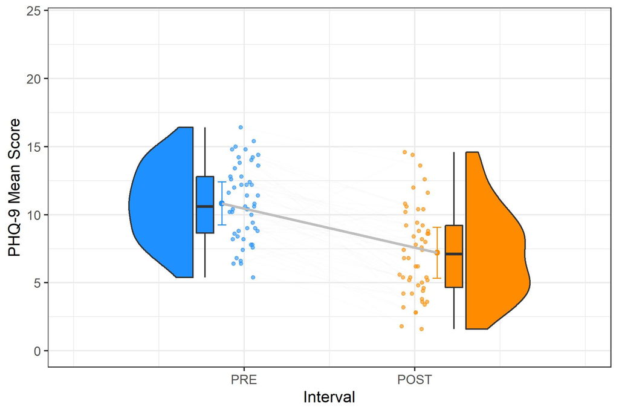

```r
#knitr::include_graphics("Time Series Dataframes/k20_PP_5.5_n50_Pre-Post_Box_Violin.jpg")
knitr::include_graphics("Time Series Dataframes/k20_PP_5.5_n50_Pre-Post_Box_Violin_Mean+CI.jpg")
```

### 1.2.2 Erweiterte Intervall-Daten (je 30 MZP)

```r
PP_30.30 %>%
  select(-(ID1_PRE:ID6_POST)) %>%
  within(., {ind.pretestSD = round(ind.pretestSD, digits = 2)
            ind.posttestSD = round(ind.posttestSD, digits = 2)}) %>%
  head() %>%
  kable() %>%
  kable_styling(bootstrap_options = c("striped", "hover", "condensed"), full_width = FALSE) %>%
  scroll_box(width = "100%")
```

| ID | PRE1_1 | PRE1_2 | PRE1_3 | PRE1_4 | PRE1_5 | PRE1_6 | PRE1_7 | PRE1_8 | PRE1_9 | PRE1_10 | PRE1_11 | PRE1_12 | PRE1_13 | PRE1_14 | PRE1_15 | PRE1_16 | PRE1_17 | PRE1_18 | PRE1_19 | PRE1_20 | PRE1_21 | PRE1_22 | PRE1_23 | PRE1_24 | PRE1_25 | PRE1_26 | PRE1_27 | PRE1_28 | PRE1_29 | … |
| --- | --- | --- | --- | --- | --- | --- | --- | --- | --- | --- | --- | --- | --- | --- | --- | --- | --- | --- | --- | --- | --- | --- | --- | --- | --- | --- | --- | --- | --- | --- |
| 16 | 11 | 12 | 15 | 23 | 14 | 23 | 15 | 12 | 11 | 14 | 11 | 15 | 23 | 14 | 12 | 11 | 12 | 14 | 15 | 23 | 11 | 23 | 12 | 14 | 15 | 11 | 12 | 15 | 23 | … |
| 82 | 3 | 6 | 6 | 9 | 9 | 10 | 7 | 3 | 6 | 7 | 7 | 7 | 3 | 6 | 10 | 10 | 7 | 3 | 6 | 7 | 4 | 4 | 9 | 9 | 7 | 7 | 7 | 3 | 6 | … |
| 103 | 15 | 15 | 12 | 14 | 12 | 11 | 15 | 14 | 14 | 14 | 13 | 13 | 16 | 12 | 14 | 16 | 13 | 12 | 13 | 14 | 14 | 14 | 14 | 15 | 11 | 12 | 12 | 15 | 15 | … |
| 259 | 15 | 14 | 14 | 12 | 15 | 13 | 13 | 14 | 16 | 14 | 16 | 13 | 14 | 13 | 14 | 14 | 15 | 12 | 15 | 14 | 12 | 14 | 14 | 15 | 15 | 13 | 14 | 14 | 13 | … |
| 356 | 10 | 10 | 11 | 14 | 13 | 12 | 11 | 12 | 14 | 9 | 9 | 12 | 14 | 11 | 12 | 14 | 11 | 9 | 12 | 12 | 13 | 14 | 11 | 10 | 10 | 12 | 9 | 14 | 12 | … |
| 481 | 13 | 12 | 11 | 7 | 11 | 9 | 8 | 11 | 13 | 13 | 14 | 12 | 10 | 8 | 10 | 13 | 11 | 11 | 12 | 7 | 12 | 14 | 10 | 8 | 10 | 12 | 14 | 10 | 10 | … |

> Pre-Post-Verläufe für 9 zufällig gezogene Personen

```r
rand = sample(PP_30.30$ID, 9)

x = tibble(ID = c(rep(rand[1],times=61),
                     rep(rand[2],times=61),
                     rep(rand[3],times=61),
                     rep(rand[4],times=61),
                     rep(rand[5],times=61),
                     rep(rand[6],times=61),
                     rep(rand[7],times=61),
                     rep(rand[8],times=61),
                     rep(rand[9],times=61)),
              MZP = rep(seq(as.Date("2020-01-01"), length.out=61, by="1 day"), times=9),
              Score = c(as.numeric(PP_30.30[rand[1],pre_30mzp]), NA, as.numeric(PP_30.30[rand[1],post_30mzp]),
                        as.numeric(PP_30.30[rand[2],pre_30mzp]), NA, as.numeric(PP_30.30[rand[2],post_30mzp]),
                        as.numeric(PP_30.30[rand[3],pre_30mzp]), NA, as.numeric(PP_30.30[rand[3],post_30mzp]),
                        as.numeric(PP_30.30[rand[4],pre_30mzp]), NA, as.numeric(PP_30.30[rand[4],post_30mzp]),
                        as.numeric(PP_30.30[rand[5],pre_30mzp]), NA, as.numeric(PP_30.30[rand[5],post_30mzp]),
                        as.numeric(PP_30.30[rand[6],pre_30mzp]), NA, as.numeric(PP_30.30[rand[6],post_30mzp]),
                        as.numeric(PP_30.30[rand[7],pre_30mzp]), NA, as.numeric(PP_30.30[rand[7],post_30mzp]),
                        as.numeric(PP_30.30[rand[8],pre_30mzp]), NA, as.numeric(PP_30.30[rand[8],post_30mzp]),
                        as.numeric(PP_30.30[rand[9],pre_30mzp]), NA, as.numeric(PP_30.30[rand[9],post_30mzp])))

x %>%
  group_by(ID) %>%
  plot_time_series(MZP, Score,
    #.color_var = ID,           # for multiple lines in one plot
    #.color_lab = "ID",
    .facet_ncol = 3,
    .facet_scales = "fixed",
    .interactive = TRUE,
    .facet_collapse = FALSE,
    .smooth = TRUE,
    .smooth_degree = 2,
    .smooth_alpha = 0.5,
    .smooth_size = 0.2
  )
```

```r
# don´t run this section (code for extremely computation-intense plots that I already stored as .RData and .jpg)
# repeated-measures scatter-boxplot-violin-histograms for individual PRE and POST means
# from van Langen (2020) Open-visualizations tutorial for repeated measures in R

# PP_30.30
# converting my dataframes to use in the same ggplot structure:
PP_30.30_ts = PP_30.30 %>%
  select(ID, PRE_Mean, POST_Mean) %>%
  pivot_longer(!ID, names_to = "Interval", values_to = "Mean") %>%
  mutate(ID = as.factor(ID),
         Interval = rep(c(1,2), times = nrow(PP_30.30)))

save(PP_30.30_ts, file = "Time Series Dataframes/k20_PP_30.30_n50_ts.RData")

###

load("Time Series Dataframes/k20_PP_30.30_n50_ts.RData")

# Repeated measures with box− and violin plots
PP_30.30_ts$jit = jitter(PP_30.30_ts$Interval, amount = .09)

Pre_Post_Box_Violin = ggplot(data = PP_30.30_ts, aes(y = Mean)) +
  geom_point(data = PP_30.30_ts %>% filter(Interval == "1"), aes(x = jit), color = "dodgerblue", size = 1,
             alpha = .5) +
  geom_point(data = PP_30.30_ts %>% filter(Interval == "2"), aes(x = jit), color = "darkorange", size = 1,
             alpha = .5) +
  geom_line(aes(x = jit, group = ID), color = "lightgray", alpha = .05) +
  geom_half_boxplot(
    data = PP_30.30_ts %>% filter(Interval == "1"), aes(x = Interval, y = Mean), position = position_nudge(x = -.25),
    side = "r", outlier.shape = NA, center = TRUE, errorbar.draw = TRUE, width = .1,
    fill = "dodgerblue", alpha = .5) +
  geom_half_boxplot(
    data = PP_30.30_ts %>% filter(Interval == "2"), aes(x = Interval, y = Mean), position = position_nudge(x = .15),
    side = "r", outlier.shape = NA, center = TRUE, errorbar.draw = TRUE, width = .1,
    fill = "darkorange", alpha = .5) +
  geom_half_violin(
    data = PP_30.30_ts %>% filter(Interval == "1"), aes(x = Interval, y = Mean), position = position_nudge(x = 1.3),
    side = "r", fill = "dodgerblue", alpha = .5, trim = FALSE) +
  geom_half_violin(
    data = PP_30.30_ts %>% filter(Interval == "2"), aes(x = Interval, y = Mean), position = position_nudge(x = .3),
    side = "r", fill = "darkorange", alpha = .5, trim = FALSE) +
  scale_x_continuous(breaks = c(1,2), labels = c("PRE", "POST"), limits = c(0, 3)) +
  xlab("Interval") + ylab("PHQ-9 Mean Score") +
  #ggtitle("Paper-Pencil Data (30+30 Timepoints): Individual Pre-Post Means") +
  #theme_classic() +
  theme_bw() +
  coord_cartesian(ylim = c(0, 24))

ggsave("Time Series Dataframes/k20_PP_30.30_n50_Pre-Post_Box_Violin.jpg", plot = Pre_Post_Box_Violin, width = 6, height = 4)
save(Pre_Post_Box_Violin, file = "Time Series Dataframes/k20_PP_30.30_n50_Pre_Post_Box_Violin.RData")


# Repeated measures with box− and violin plots and means + CIs
score_mean_1 = PP_30.30_ts %>% filter(Interval == "1") %>% summarise(mean(Mean)) %>% as.numeric()
score_mean_2 = PP_30.30_ts %>% filter(Interval == "2") %>% summarise(mean(Mean)) %>% as.numeric()
score_median1 = PP_30.30_ts %>% filter(Interval == "1") %>% summarise(median(Mean)) %>% as.numeric()
score_median2 = PP_30.30_ts %>% filter(Interval == "2") %>% summarise(median(Mean)) %>% as.numeric()
score_sd_1 = PP_30.30_ts %>% filter(Interval == "1") %>% summarise(sd(Mean)) %>% as.numeric()
score_sd_2 = PP_30.30_ts %>% filter(Interval == "2") %>% summarise(sd(Mean)) %>% as.numeric()
score_se_1 = score_sd_1/sqrt(nrow(PP_30.30))
score_se_2 = score_sd_2/sqrt(nrow(PP_30.30))
score_ci_1 = PP_30.30_ts %>% filter(Interval == "1") %>% pull(Mean) %>% CI(., ci = 0.95)
score_ci_2 = PP_30.30_ts %>% filter(Interval == "2") %>% pull(Mean) %>% CI(., ci = 0.95)
#Create data frame with 2 rows and 7 columns containing the descriptives
group = c("PRE", "POST")
N = c(nrow(PP_30.30), nrow(PP_30.30))
score_mean = c(score_mean_1, score_mean_2)
score_median = c(score_median1, score_median2)
sd = c(score_sd_1, score_sd_2)
se = c(score_se_1, score_se_2)
ci = c((score_ci_1[1] - score_ci_1[3]), (score_ci_2[1] - score_ci_2[3]))
summary_df = data.frame(group, N, score_mean, score_median, sd, se, ci)

# PP_30.30_ts$jit = jitter(PP_30.30_ts$Interval, amount = .09)     #already created above
x_tick_means = c(.87, 2.13)

Pre_Post_Box_Violin_Mean_CI = ggplot(data = PP_30.30_ts, aes(y = Mean)) +
  geom_point(data = PP_30.30_ts %>% filter(Interval == "1"), aes(x = jit), color = "dodgerblue", size = 1,
             alpha = .6) +
  geom_point(data = PP_30.30_ts %>% filter(Interval == "2"), aes(x = jit), color = "darkorange", size = 1,
             alpha = .6) +
  geom_line(aes(x = jit, group = ID), color = "lightgray", alpha = .05) +
  geom_half_boxplot(
    data = PP_30.30_ts %>% filter(Interval == "1"), aes(x = Interval, y = Mean), position = position_nudge(x = -.28),
    side = "r", outlier.shape = NA, center = TRUE, errorbar.draw = FALSE, width = .2,
    fill = "dodgerblue") +
  geom_half_boxplot(
    data = PP_30.30_ts %>% filter(Interval == "2"), aes(x = Interval, y = Mean), position = position_nudge(x = .18),
    side = "r", outlier.shape = NA, center = TRUE, errorbar.draw = FALSE, width = .2,
    fill = "darkorange") +
  geom_half_violin(
    data = PP_30.30_ts %>% filter(Interval == "1"), aes(x = Interval, y = Mean), position = position_nudge(x = -.3),
    side = "l", fill = "dodgerblue") +
  geom_half_violin(
    data = PP_30.30_ts %>% filter(Interval == "2"),aes(x = Interval, y = Mean), position = position_nudge(x = .3),
    side = "r", fill = "darkorange") +
  geom_point(data = PP_30.30_ts %>% filter(Interval == "1"), aes(x = Interval, y = score_mean[1]),
             position = position_nudge(x = -.13), color = "dodgerblue", alpha = .6, size = 1.5) +
  geom_errorbar(data = PP_30.30_ts %>% filter(Interval == "1"), aes(x = Interval, y = score_mean[1],
                                                 ymin = score_mean[1]-ci[1], ymax = score_mean[1]+ci[1]),
                position = position_nudge(-.13), color = "dodgerblue", width = 0.05, size = 0.4, alpha = .6) +
  geom_point(data = PP_30.30_ts %>% filter(Interval == "2"), aes(x = Interval, y = score_mean[2]),
             position = position_nudge(x = .13), color = "darkorange", alpha = .6, size = 1.5)+
  geom_errorbar(data = PP_30.30_ts %>% filter(Interval == "2"), aes(x = Interval, y = score_mean[2],
                                                 ymin = score_mean[2]-ci[2], ymax = score_mean[2]+ci[2]),
                position = position_nudge(.13), color = "darkorange", width = 0.05, size = 0.4, alpha = .6) +
  geom_line(data = summary_df, aes(x = x_tick_means, y = score_mean), color = "gray", size = 1) +
  scale_x_continuous(breaks = c(1,2), labels = c("PRE", "POST"), limits = c(0, 3)) +
  xlab("Interval") + ylab("PHQ-9 Mean Score") +
  #ggtitle("Paper-Pencil Data (30+30 Timepoints): Individual Pre-Post Means") +
  #theme_classic() +
  theme_bw() +
  coord_cartesian(ylim = c(0, 24))

ggsave("Time Series Dataframes/k20_PP_30.30_n50_Pre-Post_Box_Violin_Mean+CI.jpg", plot = Pre_Post_Box_Violin_Mean_CI, width = 6, height = 4)
save(Pre_Post_Box_Violin_Mean_CI, file = "Time Series Dataframes/k20_PP_30.30_n50_Pre_Post_Box_Violin_Mean_CI.RData")
```

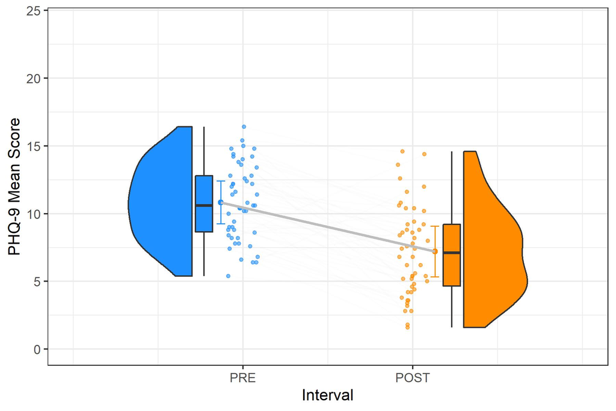

```r
#knitr::include_graphics("Time Series Dataframes/k20_PP_30.30_n50_Pre-Post_Box_Violin.jpg")
knitr::include_graphics("Time Series Dataframes/k20_PP_30.30_n50_Pre-Post_Box_Violin_Mean+CI.jpg")
```

### 1.2.3 Stichprobe mit je 1 MZP

```r
kable(head(PP_1.1)) %>%
  kable_styling(bootstrap_options = c("striped", "hover", "condensed"), full_width = FALSE)
```

| ID | ID_orig | PRE | POST | Diff |
| --- | --- | --- | --- | --- |
| 16 | 18 | 11 | 10 | 1 |
| 82 | 91 | 3 | 2 | 1 |
| 103 | 113 | 15 | 3 | 12 |
| 259 | 289 | 15 | 2 | 13 |
| 356 | 401 | 10 | 11 | -1 |
| 481 | 550 | 13 | 10 | 3 |

> Pre-Post-Verläufe für 9 zufällig gezogene Personen

```r
rand = sample(PP_1.1$ID, 9)

x = tibble(ID = c(rep(rand[1],times=3),
                     rep(rand[2],times=3),
                     rep(rand[3],times=3),
                     rep(rand[4],times=3),
                     rep(rand[5],times=3),
                     rep(rand[6],times=3),
                     rep(rand[7],times=3),
                     rep(rand[8],times=3),
                     rep(rand[9],times=3)),
              MZP = rep(seq(as.Date("2020-01-01"), length.out=3, by="1 day"), times=9),
              Score = c(as.numeric(PP_1.1[rand[1],"PRE"]), NA, as.numeric(PP_1.1[rand[1],"POST"]),
                        as.numeric(PP_1.1[rand[2],"PRE"]), NA, as.numeric(PP_1.1[rand[2],"POST"]),
                        as.numeric(PP_1.1[rand[3],"PRE"]), NA, as.numeric(PP_1.1[rand[3],"POST"]),
                        as.numeric(PP_1.1[rand[4],"PRE"]), NA, as.numeric(PP_1.1[rand[4],"POST"]),
                        as.numeric(PP_1.1[rand[5],"PRE"]), NA, as.numeric(PP_1.1[rand[5],"POST"]),
                        as.numeric(PP_1.1[rand[6],"PRE"]), NA, as.numeric(PP_1.1[rand[6],"POST"]),
                        as.numeric(PP_1.1[rand[7],"PRE"]), NA, as.numeric(PP_1.1[rand[7],"POST"]),
                        as.numeric(PP_1.1[rand[8],"PRE"]), NA, as.numeric(PP_1.1[rand[8],"POST"]),
                        as.numeric(PP_1.1[rand[9],"PRE"]), NA, as.numeric(PP_1.1[rand[9],"POST"])))

x %>%
  group_by(ID) %>%
  plot_time_series(MZP, Score,
    #.color_var = ID,           # for multiple lines in one plot
    #.color_lab = "ID",
    .facet_ncol = 3,
    .facet_scales = "fixed",
    .interactive = TRUE,
    .facet_collapse = FALSE,
    .smooth = TRUE,
    .smooth_degree = 2,
    .smooth_alpha = 0.5,
    .smooth_size = 0.2
  )
```

```r
# don´t run this section (code for extremely computation-intense plots that I already stored as .RData and .jpg)
# repeated-measures scatter-boxplot-violin-histograms for individual PRE and POST means
# from van Langen (2020) Open-visualizations tutorial for repeated measures in R

# PP_1.1
# converting my dataframes to use in the same ggplot structure:
PP_1.1_ts = PP_1.1 %>%
  select(ID, PRE, POST) %>%
  pivot_longer(!ID, names_to = "Timepoint", values_to = "Score") %>%
  mutate(ID = as.factor(ID),
         Timepoint = rep(c(1,2), times = nrow(PP_5.5)))

save(PP_1.1_ts, file = "Time Series Dataframes/k20_PP_1.1_n50_ts.RData")

###

load("Time Series Dataframes/k20_PP_1.1_n50_ts.RData")

# Repeated measures with box− and violin plots
PP_1.1_ts$jit = jitter(PP_1.1_ts$Timepoint, amount = .09)

Pre_Post_Box_Violin = ggplot(data = PP_1.1_ts, aes(y = Score)) +
  geom_point(data = PP_1.1_ts %>% filter(Timepoint == "1"), aes(x = jit), color = "dodgerblue", size = 1,
             alpha = .5) +
  geom_point(data = PP_1.1_ts %>% filter(Timepoint == "2"), aes(x = jit), color = "darkorange", size = 1,
             alpha = .5) +
  geom_line(aes(x = jit, group = ID), color = "lightgray", alpha = .05) +
  geom_half_boxplot(
    data = PP_1.1_ts %>% filter(Timepoint == "1"), aes(x = Timepoint, y = Score), position = position_nudge(x = -.25),
    side = "r", outlier.shape = NA, center = TRUE, errorbar.draw = TRUE, width = .1,
    fill = "dodgerblue", alpha = .5) +
  geom_half_boxplot(
    data = PP_1.1_ts %>% filter(Timepoint == "2"), aes(x = Timepoint, y = Score), position = position_nudge(x = .15),
    side = "r", outlier.shape = NA, center = TRUE, errorbar.draw = TRUE, width = .1,
    fill = "darkorange", alpha = .5) +
  geom_half_violin(
    data = PP_1.1_ts %>% filter(Timepoint == "1"), aes(x = Timepoint, y = Score), position = position_nudge(x = 1.3),
    side = "r", fill = "dodgerblue", alpha = .5, trim = FALSE) +
  geom_half_violin(
    data = PP_1.1_ts %>% filter(Timepoint == "2"), aes(x = Timepoint, y = Score), position = position_nudge(x = .3),
    side = "r", fill = "darkorange", alpha = .5, trim = FALSE) +
  scale_x_continuous(breaks = c(1,2), labels = c("PRE", "POST"), limits = c(0, 3)) +
  xlab("Single Assessment") + ylab("PHQ-9 Score") +
  #ggtitle("Paper-Pencil Data (1+1 Timepoints): Individual Pre-Post Means") +
  #theme_classic() +
  theme_bw() +
  coord_cartesian(ylim = c(0, 24))

ggsave("Time Series Dataframes/k20_PP_1.1_n50_Pre-Post_Box_Violin.jpg", plot = Pre_Post_Box_Violin, width = 6, height = 4)
save(Pre_Post_Box_Violin, file = "Time Series Dataframes/k20_PP_1.1_n50_Pre_Post_Box_Violin.RData")


# Repeated measures with box− and violin plots and means + CIs
score_mean_1 = PP_1.1_ts %>% filter(Timepoint == "1") %>% summarise(mean(Score)) %>% as.numeric()
score_mean_2 = PP_1.1_ts %>% filter(Timepoint == "2") %>% summarise(mean(Score)) %>% as.numeric()
score_median1 = PP_1.1_ts %>% filter(Timepoint == "1") %>% summarise(median(Score)) %>% as.numeric()
score_median2 = PP_1.1_ts %>% filter(Timepoint == "2") %>% summarise(median(Score)) %>% as.numeric()
score_sd_1 = PP_1.1_ts %>% filter(Timepoint == "1") %>% summarise(sd(Score)) %>% as.numeric()
score_sd_2 = PP_1.1_ts %>% filter(Timepoint == "2") %>% summarise(sd(Score)) %>% as.numeric()
score_se_1 = score_sd_1/sqrt(nrow(PP_1.1))
score_se_2 = score_sd_2/sqrt(nrow(PP_1.1))
score_ci_1 = PP_1.1_ts %>% filter(Timepoint == "1") %>% pull(Score) %>% CI(., ci = 0.95)
score_ci_2 = PP_1.1_ts %>% filter(Timepoint == "2") %>% pull(Score) %>% CI(., ci = 0.95)
#Create data frame with 2 rows and 7 columns containing the descriptives
group = c("PRE", "POST")
N = c(nrow(PP_1.1), nrow(PP_1.1))
score_mean = c(score_mean_1, score_mean_2)
score_median = c(score_median1, score_median2)
sd = c(score_sd_1, score_sd_2)
se = c(score_se_1, score_se_2)
ci = c((score_ci_1[1] - score_ci_1[3]), (score_ci_2[1] - score_ci_2[3]))
summary_df = data.frame(group, N, score_mean, score_median, sd, se, ci)

# PP_1.1_ts$jit = jitter(PP_1.1_ts$Timepoint, amount = .09)     #already created above
x_tick_means = c(.87, 2.13)

Pre_Post_Box_Violin_Mean_CI = ggplot(data = PP_1.1_ts, aes(y = Score)) +
  geom_point(data = PP_1.1_ts %>% filter(Timepoint == "1"), aes(x = jit), color = "dodgerblue", size = 1,
             alpha = .6) +
  geom_point(data = PP_1.1_ts %>% filter(Timepoint == "2"), aes(x = jit), color = "darkorange", size = 1,
             alpha = .6) +
  geom_line(aes(x = jit, group = ID), color = "lightgray", alpha = .05) +
  geom_half_boxplot(
    data = PP_1.1_ts %>% filter(Timepoint == "1"), aes(x = Timepoint, y = Score), position = position_nudge(x = -.28),
    side = "r", outlier.shape = NA, center = TRUE, errorbar.draw = FALSE, width = .2,
    fill = "dodgerblue") +
  geom_half_boxplot(
    data = PP_1.1_ts %>% filter(Timepoint == "2"), aes(x = Timepoint, y = Score), position = position_nudge(x = .18),
    side = "r", outlier.shape = NA, center = TRUE, errorbar.draw = FALSE, width = .2,
    fill = "darkorange") +
  geom_half_violin(
    data = PP_1.1_ts %>% filter(Timepoint == "1"), aes(x = Timepoint, y = Score), position = position_nudge(x = -.3),
    side = "l", fill = "dodgerblue") +
  geom_half_violin(
    data = PP_1.1_ts %>% filter(Timepoint == "2"),aes(x = Timepoint, y = Score), position = position_nudge(x = .3),
    side = "r", fill = "darkorange") +
  geom_point(data = PP_1.1_ts %>% filter(Timepoint == "1"), aes(x = Timepoint, y = score_mean[1]),
             position = position_nudge(x = -.13), color = "dodgerblue", alpha = .6, size = 1.5) +
  geom_errorbar(data = PP_1.1_ts %>% filter(Timepoint == "1"), aes(x = Timepoint, y = score_mean[1],
                                                 ymin = score_mean[1]-ci[1], ymax = score_mean[1]+ci[1]),
                position = position_nudge(-.13), color = "dodgerblue", width = 0.05, size = 0.4, alpha = .6) +
  geom_point(data = PP_1.1_ts %>% filter(Timepoint == "2"), aes(x = Timepoint, y = score_mean[2]),
             position = position_nudge(x = .13), color = "darkorange", alpha = .6, size = 1.5)+
  geom_errorbar(data = PP_1.1_ts %>% filter(Timepoint == "2"), aes(x = Timepoint, y = score_mean[2],
                                                 ymin = score_mean[2]-ci[2], ymax = score_mean[2]+ci[2]),
                position = position_nudge(.13), color = "darkorange", width = 0.05, size = 0.4, alpha = .6) +
  geom_line(data = summary_df, aes(x = x_tick_means, y = score_mean), color = "gray", size = 1) +
  scale_x_continuous(breaks = c(1,2), labels = c("PRE", "POST"), limits = c(0, 3)) +
  xlab("Single Assessment") + ylab("PHQ-9 Score") +
  #ggtitle("Paper-Pencil Data (1+1 Timepoints): Individual Pre-Post Means") +
  #theme_classic() +
  theme_bw() +
  coord_cartesian(ylim = c(0, 24))

ggsave("Time Series Dataframes/k20_PP_1.1_n50_Pre-Post_Box_Violin_Mean+CI.jpg", plot = Pre_Post_Box_Violin_Mean_CI, width = 6, height = 4)
save(Pre_Post_Box_Violin_Mean_CI, file = "Time Series Dataframes/k20_PP_1.1_n50_Pre_Post_Box_Violin_Mean_CI.RData")
```

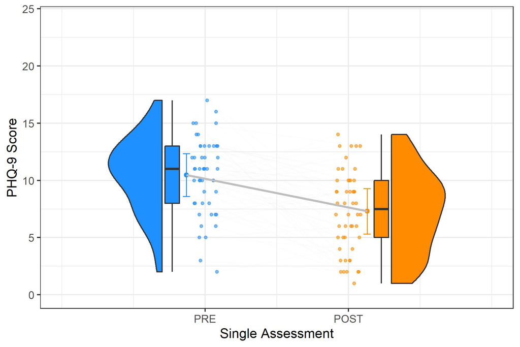

```r
#knitr::include_graphics("Time Series Dataframes/k20_PP_1.1_n50_Pre-Post_Box_Violin.jpg")
knitr::include_graphics("Time Series Dataframes/k20_PP_1.1_n50_Pre-Post_Box_Violin_Mean+CI.jpg")
```

## 1.3 Deskriptive Statistiken der Datensets

```r
tibble(Descriptives = c("mean_PRE_Mean","mean_POST_Mean","mean_MeanDiff","mean_PRE_1MZP","mean_POST_1MZP",
                        "mean_Diff_1MZP","mean_ind.pretestSD","mean_ind.posttestSD","sd_PRE_1MZP","sd_POST_1MZP"),
       PP_5.5 = round(c(mean(PP_5.5$PRE_Mean),mean(PP_5.5$POST_Mean),mean(PP_5.5$MeanDiff),NA,NA,NA,
                       mean(PP_5.5$ind.pretestSD),mean(PP_5.5$ind.posttestSD),NA,NA), digits = 3),
       PP_30.30 = round(c(mean(PP_30.30$PRE_Mean),mean(PP_30.30$POST_Mean),mean(PP_30.30$MeanDiff),
                         NA,NA,NA,mean(PP_30.30$ind.pretestSD),mean(PP_30.30$ind.posttestSD),NA,NA), digits = 3),
       PP_1.1 = round(c(NA,NA,NA,mean(PP_1.1$PRE),mean(PP_1.1$POST),mean(PP_1.1$Diff),
                          NA,NA,sd(PP_1.1$PRE),sd(PP_1.1$POST)), digits = 3)) %>%
  kable() %>%
  kable_styling(bootstrap_options = c("striped", "hover", "condensed"), full_width = FALSE)
```

| Descriptives | PP_5.5 | PP_30.30 | PP_1.1 |
| --- | --- | --- | --- |
| mean_PRE_Mean | 10.836 | 10.836 | NA |
| mean_POST_Mean | 7.212 | 7.212 | NA |
| mean_MeanDiff | 3.624 | 3.624 | NA |
| mean_PRE_1MZP | NA | NA | 10.460 |
| mean_POST_1MZP | NA | NA | 7.300 |
| mean_Diff_1MZP | NA | NA | 3.160 |
| mean_ind.pretestSD | 2.288 | 2.082 | NA |
| mean_ind.posttestSD | 2.512 | 2.286 | NA |
| sd_PRE_1MZP | NA | NA | 3.290 |
| sd_POST_1MZP | NA | NA | 3.507 |

> Boxplots der Pre- und Post-(Mittel-)Werte

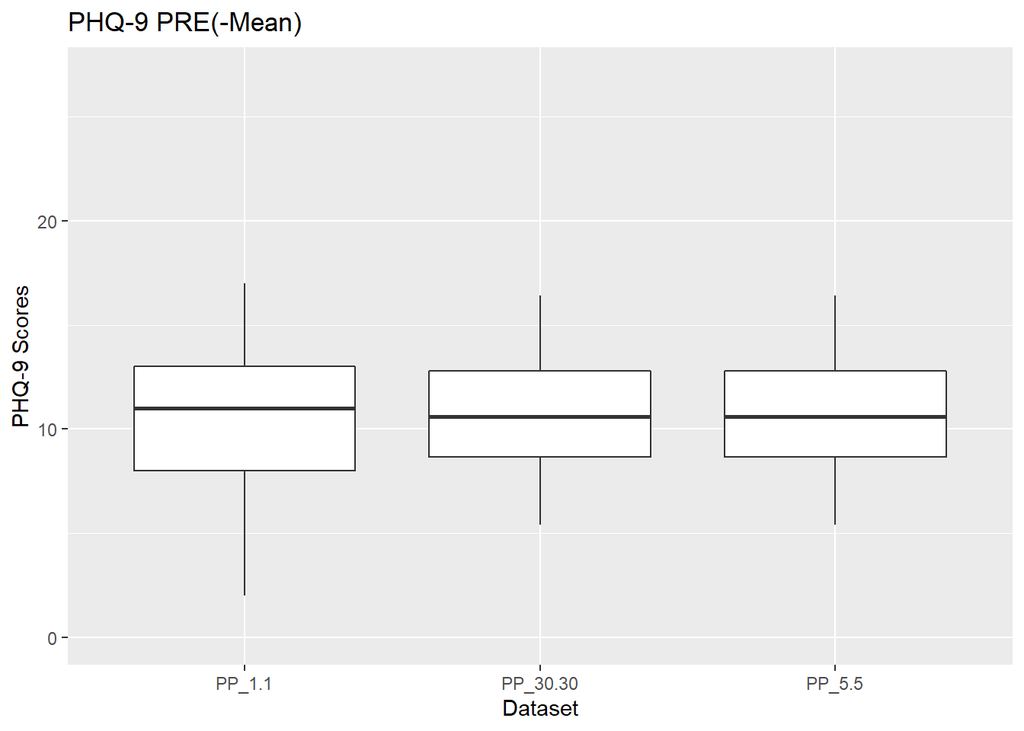

```r
# Boxplots zum Vergleich
temp = tibble(Scores = c(PP_5.5$PRE_Mean, PP_30.30$PRE_Mean, PP_1.1$PRE),
              Datasets = rep(c("PP_5.5", "PP_30.30", "PP_1.1"), each = length(PP_5.5$PRE_Mean)))

ggplot(temp, aes(x = Datasets, y = Scores)) +
  geom_boxplot() +
  ylim(0, 27) +
  ggtitle("PHQ-9 PRE(-Mean)") +
  xlab("Dataset") +
  ylab("PHQ-9 Scores")
```

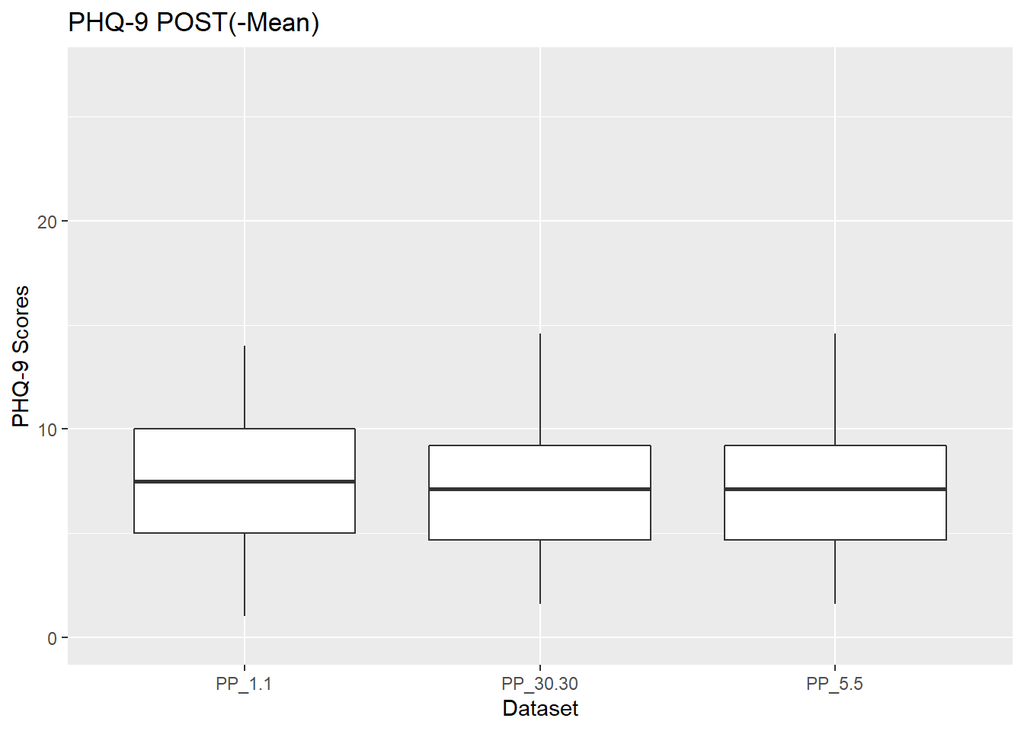

```r
temp = tibble(Scores = c(PP_5.5$POST_Mean, PP_30.30$POST_Mean, PP_1.1$POST),
              Datasets = rep(c("PP_5.5", "PP_30.30", "PP_1.1"), each = length(PP_5.5$POST_Mean)))

ggplot(temp, aes(x = Datasets, y = Scores)) +
  geom_boxplot() +
  ylim(0, 27) +
  ggtitle("PHQ-9 POST(-Mean)") +
  xlab("Dataset") +
  ylab("PHQ-9 Scores")
```

> Prozentuale Überlappung der Pre-(Mittel-)Werte

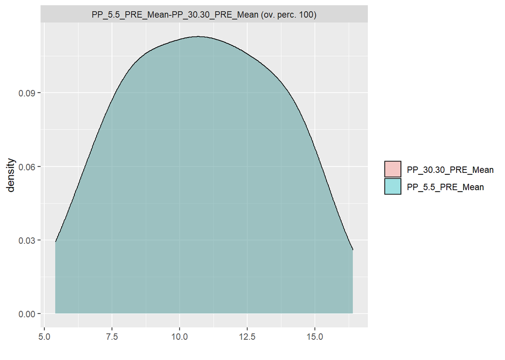

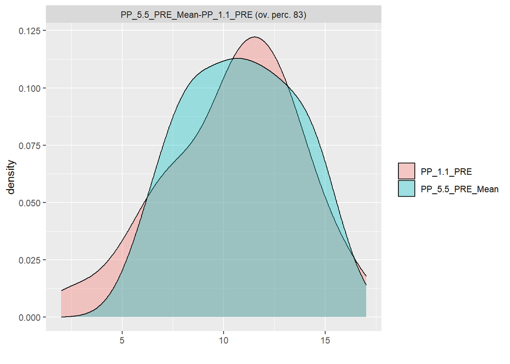

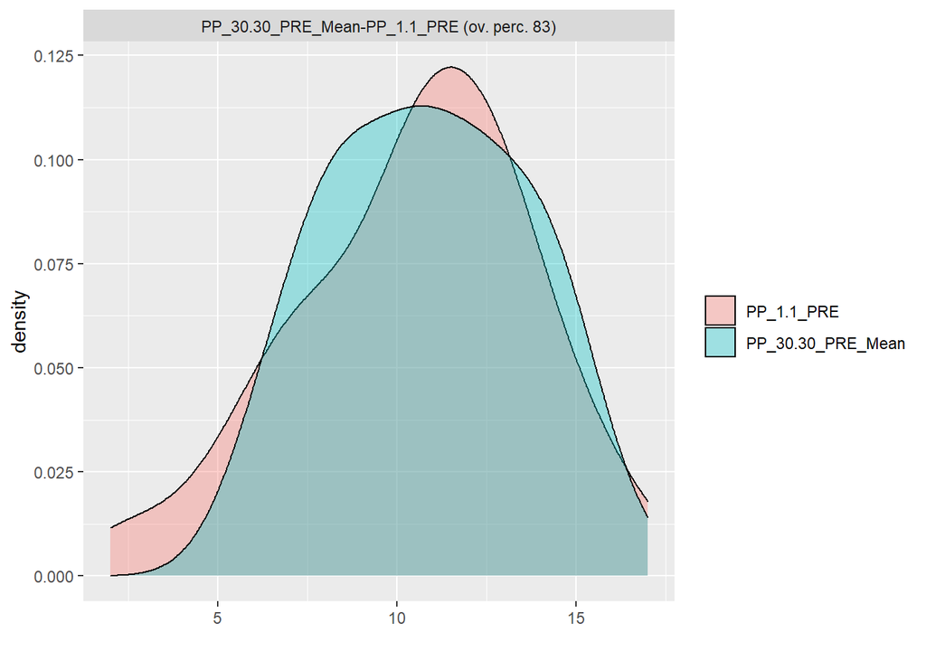

```r
# Overlap-Plots zum Vergleich
final.plot(list(PP_5.5_PRE_Mean = PP_5.5$PRE_Mean, PP_30.30_PRE_Mean = PP_30.30$PRE_Mean),
           overlap(list(PP_5.5_PRE_Mean = PP_5.5$PRE_Mean, PP_30.30_PRE_Mean = PP_30.30$PRE_Mean))$OV)

final.plot(list(PP_5.5_PRE_Mean = PP_5.5$PRE_Mean, PP_1.1_PRE = PP_1.1$PRE),
           overlap(list(PP_5.5_PRE_Mean = PP_5.5$PRE_Mean, PP_1.1_PRE = PP_1.1$PRE))$OV)

final.plot(list(PP_30.30_PRE_Mean = PP_30.30$PRE_Mean, PP_1.1_PRE = PP_1.1$PRE),
           overlap(list(PP_30.30_PRE_Mean = PP_30.30$PRE_Mean, PP_1.1_PRE = PP_1.1$PRE))$OV)
```

> Prozentuale Überlappung der Post-(Mittel-)Werte

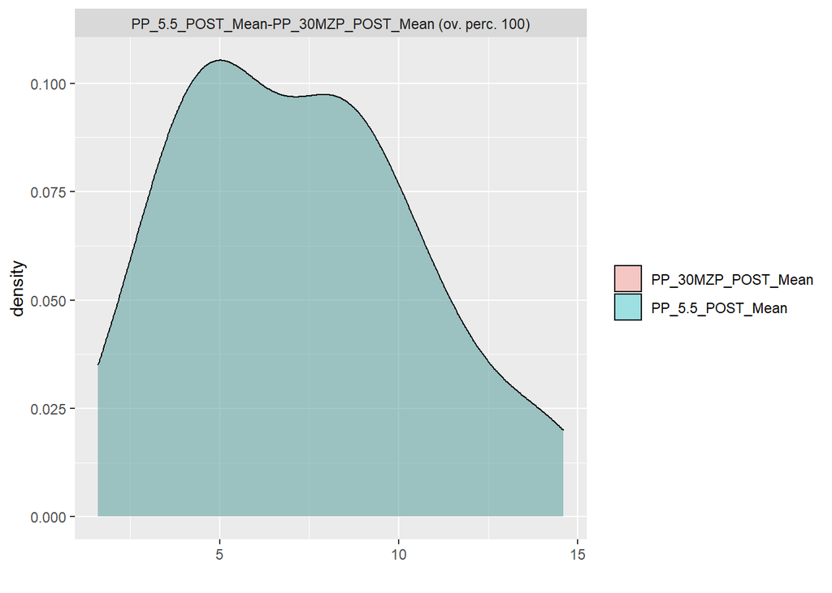

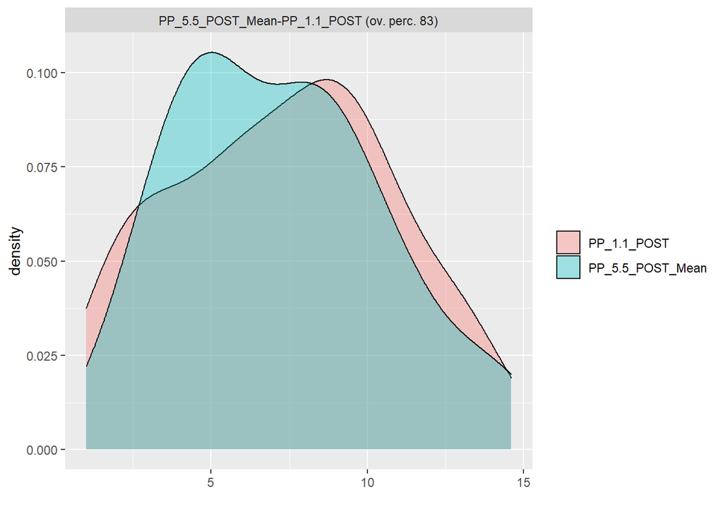

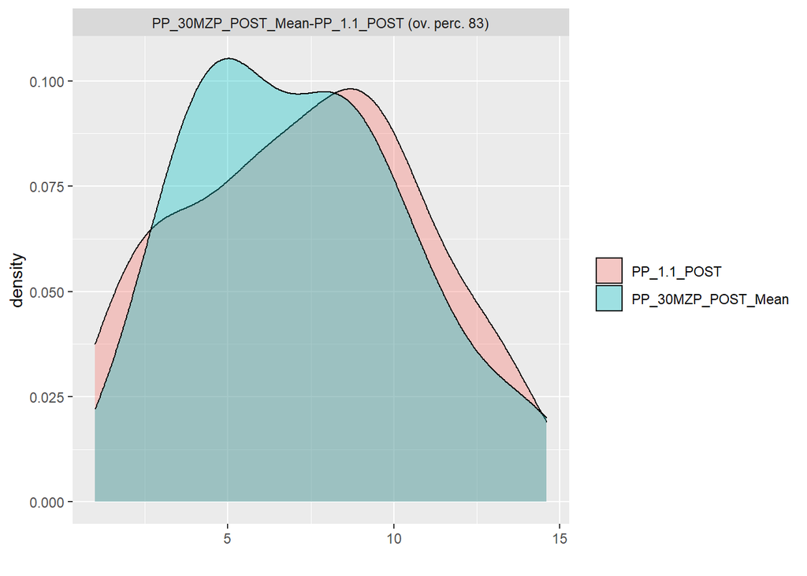

```r
# Overlap-Plots zum Vergleich
final.plot(list(PP_5.5_POST_Mean = PP_5.5$POST_Mean, PP_30MZP_POST_Mean = PP_30.30$POST_Mean),
           overlap(list(PP_5.5_POST_Mean = PP_5.5$POST_Mean, PP_30MZP_POST_Mean = PP_30.30$POST_Mean))$OV)

final.plot(list(PP_5.5_POST_Mean = PP_5.5$POST_Mean, PP_1.1_POST = PP_1.1$POST),
           overlap(list(PP_5.5_POST_Mean = PP_5.5$POST_Mean, PP_1.1_POST = PP_1.1$POST))$OV)

final.plot(list(PP_30MZP_POST_Mean = PP_30.30$POST_Mean, PP_1.1_POST = PP_1.1$POST),
           overlap(list(PP_30MZP_POST_Mean = PP_30.30$POST_Mean, PP_1.1_POST = PP_1.1$POST))$OV)
```

## 1.4 Reliabilitäten und Inter-Item-Korrelationen

### 1.4.1 PP_5.5 (je 5 MZP)

```r
# Korrelationsmatrix von PRE- und POST-MZP:
PP_5.5_KorMat = cor(PP_5.5[, c(pre_5mzp, post_5mzp)]) %>%
  round(., digits = 2)

# durchschnittliche paarweise Korrelation zwischen aufeinanderfolgenden MZP (Fisher-Z-transformiert):
pre_inter_item_rtt = 0L
for (i in 1:4) {
  pre_inter_item_rtt = pre_inter_item_rtt + FisherZ(PP_5.5_KorMat[i,i+1])
}
pre_inter_item_rtt = FisherZInv(pre_inter_item_rtt / 4)

post_inter_item_rtt = 0L
for (i in 5:9) {
  post_inter_item_rtt = post_inter_item_rtt + FisherZ(PP_5.5_KorMat[i,i+1])
}
post_inter_item_rtt = FisherZInv(post_inter_item_rtt / 4)


for (i in 1:9) {
  PP_5.5_KorMat[i, i+1] = cell_spec(PP_5.5_KorMat[i, i+1], "html", bold = TRUE)
}

rownames(PP_5.5_KorMat) = cell_spec(rownames(PP_5.5_KorMat), "html", bold = TRUE)

PP_5.5_KorMat %>%
  kable(., format = "html", escape = FALSE) %>%
  kable_styling(bootstrap_options = c("striped", "hover", "condensed"),
                full_width = FALSE, fixed_thead = T)
```

|  | PRE1_1 | PRE1_2 | PRE1_3 | PRE1_4 | PRE1_5 | POST1_1 | POST1_2 | POST1_3 | POST1_4 | POST1_5 |
| --- | --- | --- | --- | --- | --- | --- | --- | --- | --- | --- |
| PRE1_1 | 1 | 0.67 | 0.51 | 0.25 | 0.24 | 0.19 | 0.12 | 0.01 | 0.11 | 0.14 |
| PRE1_2 | 0.67 | 1 | 0.68 | 0.46 | 0.49 | 0.38 | 0.28 | 0.08 | 0.01 | 0.13 |
| PRE1_3 | 0.51 | 0.68 | 1 | 0.63 | 0.63 | 0.26 | 0.27 | 0.12 | 0.3 | 0.47 |
| PRE1_4 | 0.25 | 0.46 | 0.63 | 1 | 0.72 | 0.18 | 0.28 | 0.18 | 0.26 | 0.28 |
| PRE1_5 | 0.24 | 0.49 | 0.63 | 0.72 | 1 | 0.33 | 0.44 | 0.27 | 0.3 | 0.29 |
| POST1_1 | 0.19 | 0.38 | 0.26 | 0.18 | 0.33 | 1 | 0.51 | 0.41 | 0.27 | 0.29 |
| POST1_2 | 0.12 | 0.28 | 0.27 | 0.28 | 0.44 | 0.51 | 1 | 0.82 | 0.64 | 0.44 |
| POST1_3 | 0.01 | 0.08 | 0.12 | 0.18 | 0.27 | 0.41 | 0.82 | 1 | 0.75 | 0.51 |
| POST1_4 | 0.11 | 0.01 | 0.3 | 0.26 | 0.3 | 0.27 | 0.64 | 0.75 | 1 | 0.74 |
| POST1_5 | 0.14 | 0.13 | 0.47 | 0.28 | 0.29 | 0.29 | 0.44 | 0.51 | 0.74 | 1 |

```r
# mittleres Cronbach´s Alpha zwischen Pre-MZP und Post-MZP:
PRE_alpha = CronbachAlpha(PP_5.5[pre_5mzp])
POST_alpha = CronbachAlpha(PP_5.5[post_5mzp])
PP_5.5_Alpha = FisherZInv(mean(c(FisherZ(PRE_alpha), FisherZ(POST_alpha))))
```

Korrelation zwischen den Pre- und Post-Intervall-Mittelwerten = 0.363.  
Durchschnittliche paarweise Korrelation zwischen aufeinanderfolgenden Pre-MZP (Fisher-Z-transformiert): r = 0.68.  
Durchschnittliche paarweise Korrelation zwischen aufeinanderfolgenden Post-MZP (Fisher-Z-transformiert): r = 0.76.  
Mittleres Cronbach´s Alpha zwischen Pre-MZP und Post-MZP = 0.851.

### 1.4.2 PP_30.30 (je 30 MZP)

```r
# Korrelationsmatrix von PRE- und POST-MZP:
PP_30.30_KorMat = cor(PP_30.30[, c(pre_30mzp, post_30mzp)]) %>%
  round(., digits = 2)

# durchschnittliche paarweise Korrelation zwischen aufeinanderfolgenden MZP (Fisher-Z-transformiert):
pre_inter_item_rtt = 0L
for (i in 1:29) {
  pre_inter_item_rtt = pre_inter_item_rtt + FisherZ(PP_30.30_KorMat[i,i+1])
}
pre_inter_item_rtt = FisherZInv(pre_inter_item_rtt / 29)

post_inter_item_rtt = 0L
for (i in 31:59) {
  post_inter_item_rtt = post_inter_item_rtt + FisherZ(PP_30.30_KorMat[i,i+1])
}
post_inter_item_rtt = FisherZInv(post_inter_item_rtt / 29)


for (i in 1:59) {
  PP_30.30_KorMat[i, i+1] = cell_spec(PP_30.30_KorMat[i, i+1], "html", bold = TRUE)
}

rownames(PP_30.30_KorMat) = cell_spec(rownames(PP_30.30_KorMat), "html", bold = TRUE)

PP_30.30_KorMat %>%
  kable(., format = "html", escape = FALSE) %>%
  kable_styling(bootstrap_options = c("striped", "hover", "condensed"),
                full_width = FALSE, fixed_thead = T) %>%
  scroll_box(height = "800px")
```

|  | PRE1_1 | PRE1_2 | PRE1_3 | PRE1_4 | PRE1_5 | PRE1_6 | PRE1_7 | PRE1_8 | PRE1_9 | PRE1_10 | PRE1_11 | PRE1_12 | PRE1_13 | PRE1_14 | PRE1_15 | PRE1_16 | PRE1_17 | PRE1_18 | PRE1_19 | PRE1_20 | PRE1_21 | PRE1_22 | PRE1_23 | PRE1_24 | PRE1_25 | PRE1_26 | PRE1_27 | PRE1_28 | PRE1_29 | … |
| --- | --- | --- | --- | --- | --- | --- | --- | --- | --- | --- | --- | --- | --- | --- | --- | --- | --- | --- | --- | --- | --- | --- | --- | --- | --- | --- | --- | --- | --- | --- |
| PRE1_1 | 1 | 0.67 | 0.51 | 0.25 | 0.24 | 0.39 | 0.45 | 0.64 | 0.52 | 0.55 | 0.44 | 0.51 | 0.6 | 0.66 | 0.33 | 0.56 | 0.47 | 0.57 | 0.56 | 0.39 | 0.58 | 0.49 | 0.46 | 0.49 | 0.51 | 0.57 | 0.53 | 0.52 | 0.44 | … |
| PRE1_2 | 0.67 | 1 | 0.68 | 0.46 | 0.49 | 0.54 | 0.7 | 0.75 | 0.62 | 0.62 | 0.62 | 0.69 | 0.7 | 0.58 | 0.61 | 0.56 | 0.62 | 0.74 | 0.68 | 0.59 | 0.68 | 0.63 | 0.73 | 0.69 | 0.51 | 0.72 | 0.72 | 0.61 | 0.57 | … |
| PRE1_3 | 0.51 | 0.68 | 1 | 0.63 | 0.63 | 0.59 | 0.79 | 0.73 | 0.76 | 0.59 | 0.81 | 0.77 | 0.73 | 0.62 | 0.49 | 0.56 | 0.69 | 0.74 | 0.79 | 0.65 | 0.64 | 0.71 | 0.63 | 0.74 | 0.74 | 0.7 | 0.65 | 0.71 | 0.79 | … |
| PRE1_4 | 0.25 | 0.46 | 0.63 | 1 | 0.72 | 0.56 | 0.73 | 0.61 | 0.66 | 0.63 | 0.55 | 0.65 | 0.71 | 0.67 | 0.6 | 0.54 | 0.7 | 0.69 | 0.58 | 0.66 | 0.55 | 0.82 | 0.68 | 0.68 | 0.45 | 0.34 | 0.58 | 0.75 | 0.79 | … |
| PRE1_5 | 0.24 | 0.49 | 0.63 | 0.72 | 1 | 0.47 | 0.7 | 0.66 | 0.71 | 0.63 | 0.54 | 0.65 | 0.66 | 0.59 | 0.73 | 0.49 | 0.67 | 0.71 | 0.69 | 0.58 | 0.68 | 0.69 | 0.71 | 0.58 | 0.5 | 0.51 | 0.66 | 0.73 | 0.65 | … |
| PRE1_6 | 0.39 | 0.54 | 0.59 | 0.56 | 0.47 | 1 | 0.59 | 0.38 | 0.34 | 0.25 | 0.42 | 0.58 | 0.66 | 0.53 | 0.36 | 0.4 | 0.32 | 0.64 | 0.57 | 0.61 | 0.47 | 0.55 | 0.56 | 0.5 | 0.49 | 0.45 | 0.51 | 0.56 | 0.58 | … |
| PRE1_7 | 0.45 | 0.7 | 0.79 | 0.73 | 0.7 | 0.59 | 1 | 0.77 | 0.58 | 0.52 | 0.67 | 0.8 | 0.73 | 0.63 | 0.57 | 0.63 | 0.63 | 0.7 | 0.73 | 0.69 | 0.61 | 0.72 | 0.71 | 0.76 | 0.62 | 0.6 | 0.64 | 0.75 | 0.73 | … |
| PRE1_8 | 0.64 | 0.75 | 0.73 | 0.61 | 0.66 | 0.38 | 0.77 | 1 | 0.67 | 0.6 | 0.63 | 0.7 | 0.71 | 0.67 | 0.65 | 0.7 | 0.68 | 0.74 | 0.71 | 0.54 | 0.67 | 0.73 | 0.72 | 0.71 | 0.56 | 0.68 | 0.68 | 0.73 | 0.67 | … |
| PRE1_9 | 0.52 | 0.62 | 0.76 | 0.66 | 0.71 | 0.34 | 0.58 | 0.67 | 1 | 0.65 | 0.74 | 0.63 | 0.68 | 0.63 | 0.59 | 0.59 | 0.8 | 0.72 | 0.65 | 0.51 | 0.7 | 0.69 | 0.64 | 0.66 | 0.59 | 0.52 | 0.63 | 0.72 | 0.7 | … |
| PRE1_10 | 0.55 | 0.62 | 0.59 | 0.63 | 0.63 | 0.25 | 0.52 | 0.6 | 0.65 | 1 | 0.51 | 0.59 | 0.65 | 0.67 | 0.62 | 0.41 | 0.73 | 0.65 | 0.65 | 0.56 | 0.67 | 0.72 | 0.61 | 0.57 | 0.43 | 0.56 | 0.67 | 0.59 | 0.6 | … |
| PRE1_11 | 0.44 | 0.62 | 0.81 | 0.55 | 0.54 | 0.42 | 0.67 | 0.63 | 0.74 | 0.51 | 1 | 0.66 | 0.54 | 0.39 | 0.33 | 0.44 | 0.67 | 0.62 | 0.7 | 0.52 | 0.59 | 0.57 | 0.51 | 0.65 | 0.68 | 0.52 | 0.55 | 0.67 | 0.68 | … |
| PRE1_12 | 0.51 | 0.69 | 0.77 | 0.65 | 0.65 | 0.58 | 0.8 | 0.7 | 0.63 | 0.59 | 0.66 | 1 | 0.72 | 0.5 | 0.4 | 0.56 | 0.59 | 0.7 | 0.73 | 0.69 | 0.55 | 0.73 | 0.66 | 0.71 | 0.66 | 0.57 | 0.64 | 0.75 | 0.73 | … |
| PRE1_13 | 0.6 | 0.7 | 0.73 | 0.71 | 0.66 | 0.66 | 0.73 | 0.71 | 0.68 | 0.65 | 0.54 | 0.72 | 1 | 0.65 | 0.47 | 0.5 | 0.57 | 0.76 | 0.77 | 0.78 | 0.73 | 0.83 | 0.62 | 0.6 | 0.58 | 0.62 | 0.68 | 0.73 | 0.76 | … |
| PRE1_14 | 0.66 | 0.58 | 0.62 | 0.67 | 0.59 | 0.53 | 0.63 | 0.67 | 0.63 | 0.67 | 0.39 | 0.5 | 0.65 | 1 | 0.62 | 0.65 | 0.65 | 0.71 | 0.62 | 0.51 | 0.66 | 0.66 | 0.71 | 0.6 | 0.51 | 0.55 | 0.65 | 0.68 | 0.6 | … |
| PRE1_15 | 0.33 | 0.61 | 0.49 | 0.6 | 0.73 | 0.36 | 0.57 | 0.65 | 0.59 | 0.62 | 0.33 | 0.4 | 0.47 | 0.62 | 1 | 0.59 | 0.7 | 0.66 | 0.45 | 0.39 | 0.59 | 0.59 | 0.76 | 0.63 | 0.25 | 0.54 | 0.62 | 0.52 | 0.48 | … |
| PRE1_16 | 0.56 | 0.56 | 0.56 | 0.54 | 0.49 | 0.4 | 0.63 | 0.7 | 0.59 | 0.41 | 0.44 | 0.56 | 0.5 | 0.65 | 0.59 | 1 | 0.58 | 0.49 | 0.39 | 0.3 | 0.5 | 0.58 | 0.61 | 0.63 | 0.43 | 0.5 | 0.58 | 0.58 | 0.49 | … |
| PRE1_17 | 0.47 | 0.62 | 0.69 | 0.7 | 0.67 | 0.32 | 0.63 | 0.68 | 0.8 | 0.73 | 0.67 | 0.59 | 0.57 | 0.65 | 0.7 | 0.58 | 1 | 0.75 | 0.51 | 0.34 | 0.7 | 0.66 | 0.7 | 0.64 | 0.49 | 0.5 | 0.62 | 0.61 | 0.71 | … |
| PRE1_18 | 0.57 | 0.74 | 0.74 | 0.69 | 0.71 | 0.64 | 0.7 | 0.74 | 0.72 | 0.65 | 0.62 | 0.7 | 0.76 | 0.71 | 0.66 | 0.49 | 0.75 | 1 | 0.67 | 0.54 | 0.74 | 0.73 | 0.78 | 0.72 | 0.5 | 0.62 | 0.69 | 0.72 | 0.73 | … |
| PRE1_19 | 0.56 | 0.68 | 0.79 | 0.58 | 0.69 | 0.57 | 0.73 | 0.71 | 0.65 | 0.65 | 0.7 | 0.73 | 0.77 | 0.62 | 0.45 | 0.39 | 0.51 | 0.67 | 1 | 0.69 | 0.75 | 0.69 | 0.58 | 0.57 | 0.68 | 0.65 | 0.66 | 0.74 | 0.71 | … |
| PRE1_20 | 0.39 | 0.59 | 0.65 | 0.66 | 0.58 | 0.61 | 0.69 | 0.54 | 0.51 | 0.56 | 0.52 | 0.69 | 0.78 | 0.51 | 0.39 | 0.3 | 0.34 | 0.54 | 0.69 | 1 | 0.43 | 0.72 | 0.57 | 0.62 | 0.58 | 0.51 | 0.59 | 0.69 | 0.62 | … |
| PRE1_21 | 0.58 | 0.68 | 0.64 | 0.55 | 0.68 | 0.47 | 0.61 | 0.67 | 0.7 | 0.67 | 0.59 | 0.55 | 0.73 | 0.66 | 0.59 | 0.5 | 0.7 | 0.74 | 0.75 | 0.43 | 1 | 0.7 | 0.52 | 0.42 | 0.38 | 0.69 | 0.72 | 0.63 | 0.57 | … |
| PRE1_22 | 0.49 | 0.63 | 0.71 | 0.82 | 0.69 | 0.55 | 0.72 | 0.73 | 0.69 | 0.72 | 0.57 | 0.73 | 0.83 | 0.66 | 0.59 | 0.58 | 0.66 | 0.73 | 0.69 | 0.72 | 0.7 | 1 | 0.64 | 0.56 | 0.39 | 0.66 | 0.77 | 0.75 | 0.65 | … |
| PRE1_23 | 0.46 | 0.73 | 0.63 | 0.68 | 0.71 | 0.56 | 0.71 | 0.72 | 0.64 | 0.61 | 0.51 | 0.66 | 0.62 | 0.71 | 0.76 | 0.61 | 0.7 | 0.78 | 0.58 | 0.57 | 0.52 | 0.64 | 1 | 0.74 | 0.43 | 0.5 | 0.7 | 0.69 | 0.64 | … |
| PRE1_24 | 0.49 | 0.69 | 0.74 | 0.68 | 0.58 | 0.5 | 0.76 | 0.71 | 0.66 | 0.57 | 0.65 | 0.71 | 0.6 | 0.6 | 0.63 | 0.63 | 0.64 | 0.72 | 0.57 | 0.62 | 0.42 | 0.56 | 0.74 | 1 | 0.57 | 0.45 | 0.58 | 0.67 | 0.73 | … |
| PRE1_25 | 0.51 | 0.51 | 0.74 | 0.45 | 0.5 | 0.49 | 0.62 | 0.56 | 0.59 | 0.43 | 0.68 | 0.66 | 0.58 | 0.51 | 0.25 | 0.43 | 0.49 | 0.5 | 0.68 | 0.58 | 0.38 | 0.39 | 0.43 | 0.57 | 1 | 0.43 | 0.33 | 0.62 | 0.73 | … |
| PRE1_26 | 0.57 | 0.72 | 0.7 | 0.34 | 0.51 | 0.45 | 0.6 | 0.68 | 0.52 | 0.56 | 0.52 | 0.57 | 0.62 | 0.55 | 0.54 | 0.5 | 0.5 | 0.62 | 0.65 | 0.51 | 0.69 | 0.66 | 0.5 | 0.45 | 0.43 | 1 | 0.62 | 0.46 | 0.38 | … |
| PRE1_27 | 0.53 | 0.72 | 0.65 | 0.58 | 0.66 | 0.51 | 0.64 | 0.68 | 0.63 | 0.67 | 0.55 | 0.64 | 0.68 | 0.65 | 0.62 | 0.58 | 0.62 | 0.69 | 0.66 | 0.59 | 0.72 | 0.77 | 0.7 | 0.58 | 0.33 | 0.62 | 1 | 0.64 | 0.51 | … |
| PRE1_28 | 0.52 | 0.61 | 0.71 | 0.75 | 0.73 | 0.56 | 0.75 | 0.73 | 0.72 | 0.59 | 0.67 | 0.75 | 0.73 | 0.68 | 0.52 | 0.58 | 0.61 | 0.72 | 0.74 | 0.69 | 0.63 | 0.75 | 0.69 | 0.67 | 0.62 | 0.46 | 0.64 | 1 | 0.66 | … |
| PRE1_29 | 0.44 | 0.57 | 0.79 | 0.79 | 0.65 | 0.58 | 0.73 | 0.67 | 0.7 | 0.6 | 0.68 | 0.73 | 0.76 | 0.6 | 0.48 | 0.49 | 0.71 | 0.73 | 0.71 | 0.62 | 0.57 | 0.65 | 0.64 | 0.73 | 0.73 | 0.38 | 0.51 | 0.66 | 1 | … |
| PRE1_30 | 0.54 | 0.66 | 0.63 | 0.68 | 0.63 | 0.46 | 0.68 | 0.65 | 0.71 | 0.65 | 0.56 | 0.6 | 0.64 | 0.69 | 0.68 | 0.61 | 0.74 | 0.72 | 0.57 | 0.52 | 0.58 | 0.6 | 0.74 | 0.74 | 0.56 | 0.46 | 0.45 | 0.6 | 0.65 | … |
| POST1_1 | 0.19 | 0.38 | 0.26 | 0.18 | 0.33 | 0.37 | 0.34 | 0.32 | 0.08 | 0.24 | 0.16 | 0.27 | 0.27 | 0.28 | 0.36 | 0.14 | 0.24 | 0.37 | 0.26 | 0.32 | 0.35 | 0.35 | 0.37 | 0.15 | 0.08 | 0.46 | 0.48 | 0.21 | 0.2 | … |
| POST1_2 | 0.12 | 0.28 | 0.27 | 0.28 | 0.44 | 0.32 | 0.3 | 0.27 | 0.25 | 0.27 | 0.29 | 0.23 | 0.29 | 0.29 | 0.32 | 0.19 | 0.39 | 0.41 | 0.27 | 0.16 | 0.35 | 0.22 | 0.41 | 0.21 | 0.24 | 0.23 | 0.35 | 0.35 | 0.27 | … |
| POST1_3 | 0.01 | 0.08 | 0.12 | 0.18 | 0.27 | 0.18 | 0.09 | 0.13 | 0.12 | 0.17 | 0.1 | 0.04 | 0.2 | 0.15 | 0.19 | 0.11 | 0.19 | 0.25 | 0.08 | 0.06 | 0.2 | 0.14 | 0.23 | 0.09 | 0.03 | 0.12 | 0.29 | 0.14 | 0.12 | … |
| POST1_4 | 0.11 | 0.01 | 0.3 | 0.26 | 0.3 | 0.12 | 0.19 | 0.27 | 0.2 | 0.25 | 0.18 | 0.1 | 0.24 | 0.23 | 0.27 | 0.22 | 0.32 | 0.24 | 0.19 | 0.06 | 0.25 | 0.2 | 0.17 | 0.18 | 0.21 | 0.19 | 0.17 | 0.19 | 0.33 | … |
| POST1_5 | 0.14 | 0.13 | 0.47 | 0.28 | 0.29 | 0.35 | 0.3 | 0.27 | 0.25 | 0.17 | 0.25 | 0.27 | 0.31 | 0.2 | 0.29 | 0.26 | 0.24 | 0.32 | 0.3 | 0.22 | 0.24 | 0.25 | 0.29 | 0.31 | 0.28 | 0.28 | 0.19 | 0.25 | 0.37 | … |
| POST1_6 | 0.14 | 0.25 | 0.22 | 0.15 | 0.27 | 0.24 | 0.25 | 0.19 | 0.15 | 0.21 | 0.1 | 0.14 | 0.34 | 0.2 | 0.24 | 0.07 | 0.12 | 0.29 | 0.26 | 0.28 | 0.27 | 0.18 | 0.37 | 0.19 | 0.04 | 0.13 | 0.37 | 0.27 | 0.2 | … |
| POST1_7 | 0.16 | 0.22 | 0.36 | 0.29 | 0.35 | 0.35 | 0.25 | 0.27 | 0.24 | 0.28 | 0.24 | 0.17 | 0.35 | 0.3 | 0.34 | 0.21 | 0.3 | 0.39 | 0.27 | 0.23 | 0.32 | 0.27 | 0.34 | 0.24 | 0.23 | 0.27 | 0.35 | 0.28 | 0.35 | … |
| POST1_8 | 0.09 | 0.18 | 0.36 | 0.24 | 0.46 | 0.23 | 0.29 | 0.29 | 0.3 | 0.24 | 0.3 | 0.27 | 0.21 | 0.25 | 0.34 | 0.28 | 0.4 | 0.36 | 0.24 | 0.08 | 0.34 | 0.22 | 0.32 | 0.24 | 0.26 | 0.28 | 0.28 | 0.32 | 0.29 | … |
| POST1_9 | 0.14 | 0.25 | 0.36 | 0.33 | 0.38 | 0.38 | 0.3 | 0.38 | 0.25 | 0.2 | 0.3 | 0.22 | 0.3 | 0.26 | 0.4 | 0.24 | 0.36 | 0.48 | 0.23 | 0.2 | 0.32 | 0.36 | 0.36 | 0.28 | 0.17 | 0.4 | 0.38 | 0.27 | 0.31 | … |
| POST1_10 | 0.02 | -0.04 | 0.11 | 0.17 | 0.17 | 0.12 | 0.13 | 0.12 | -0.01 | 0.14 | 0.05 | 0.11 | 0.1 | 0.12 | 0.1 | 0.12 | 0.19 | 0.07 | 0.1 | 0.01 | 0.12 | 0.12 | 0.09 | 0.01 | 0.12 | 0.16 | 0.08 | 0.01 | 0.15 | … |
| POST1_11 | 0.11 | 0.23 | 0.26 | 0.2 | 0.31 | 0.36 | 0.21 | 0.22 | 0.18 | 0.15 | 0.29 | 0.13 | 0.21 | 0.21 | 0.26 | 0.16 | 0.14 | 0.23 | 0.27 | 0.3 | 0.24 | 0.13 | 0.34 | 0.24 | 0.21 | 0.22 | 0.34 | 0.24 | 0.17 | … |
| POST1_12 | 0.08 | 0.22 | 0.32 | 0.32 | 0.4 | 0.38 | 0.27 | 0.29 | 0.19 | 0.26 | 0.18 | 0.21 | 0.4 | 0.27 | 0.3 | 0.14 | 0.25 | 0.33 | 0.38 | 0.26 | 0.33 | 0.26 | 0.37 | 0.18 | 0.25 | 0.21 | 0.32 | 0.29 | 0.39 | … |
| POST1_13 | 0.06 | 0.14 | 0.18 | 0.17 | 0.26 | 0.28 | 0.15 | 0.16 | 0.08 | 0.17 | 0.01 | 0.04 | 0.27 | 0.22 | 0.29 | 0.07 | 0.24 | 0.32 | 0.14 | 0.07 | 0.3 | 0.16 | 0.24 | 0.05 | 0.05 | 0.2 | 0.24 | 0.09 | 0.23 | … |
| POST1_14 | 0.1 | 0.11 | 0.28 | 0.19 | 0.25 | 0.2 | 0.23 | 0.29 | 0.12 | 0.13 | 0.21 | 0.17 | 0.18 | 0.17 | 0.22 | 0.22 | 0.28 | 0.31 | 0.11 | 0.05 | 0.17 | 0.23 | 0.3 | 0.19 | 0.08 | 0.29 | 0.27 | 0.17 | 0.19 | … |
| POST1_15 | 0.19 | 0.14 | 0.38 | 0.31 | 0.39 | 0.12 | 0.33 | 0.29 | 0.35 | 0.36 | 0.29 | 0.34 | 0.24 | 0.27 | 0.32 | 0.32 | 0.46 | 0.38 | 0.19 | 0.12 | 0.31 | 0.36 | 0.22 | 0.29 | 0.26 | 0.32 | 0.26 | 0.34 | 0.32 | … |
| POST1_16 | 0.13 | 0.22 | 0.24 | 0.31 | 0.34 | 0.28 | 0.27 | 0.31 | 0.17 | 0.25 | 0.13 | 0.1 | 0.3 | 0.41 | 0.33 | 0.26 | 0.2 | 0.22 | 0.3 | 0.29 | 0.32 | 0.35 | 0.29 | 0.13 | 0.15 | 0.34 | 0.4 | 0.23 | 0.23 | … |
| POST1_17 | 0.09 | 0.13 | 0.33 | 0.29 | 0.36 | 0.24 | 0.22 | 0.32 | 0.26 | 0.21 | 0.23 | 0.18 | 0.22 | 0.31 | 0.31 | 0.25 | 0.3 | 0.29 | 0.25 | 0.15 | 0.25 | 0.24 | 0.3 | 0.23 | 0.24 | 0.26 | 0.3 | 0.29 | 0.28 | … |
| POST1_18 | 0.06 | 0.22 | 0.31 | 0.2 | 0.38 | 0.36 | 0.21 | 0.23 | 0.17 | 0.21 | 0.26 | 0.18 | 0.22 | 0.15 | 0.36 | 0.11 | 0.3 | 0.39 | 0.24 | 0.13 | 0.29 | 0.17 | 0.32 | 0.28 | 0.14 | 0.21 | 0.35 | 0.26 | 0.24 | … |
| POST1_19 | 0.14 | 0.12 | 0.28 | 0.15 | 0.19 | 0.2 | 0.19 | 0.14 | 0.16 | 0.2 | 0.18 | 0.15 | 0.3 | 0.1 | 0.15 | 0.11 | 0.27 | 0.29 | 0.15 | 0.08 | 0.28 | 0.14 | 0.2 | 0.15 | 0.12 | 0.18 | 0.19 | 0.1 | 0.27 | … |
| POST1_20 | 0.12 | 0.17 | 0.25 | 0.24 | 0.36 | 0.26 | 0.31 | 0.25 | 0.15 | 0.22 | 0.19 | 0.28 | 0.26 | 0.17 | 0.28 | 0.18 | 0.3 | 0.39 | 0.16 | 0.14 | 0.24 | 0.26 | 0.36 | 0.16 | 0.18 | 0.26 | 0.21 | 0.25 | 0.28 | … |
| POST1_21 | 0.22 | 0.19 | 0.29 | 0.36 | 0.41 | 0.3 | 0.3 | 0.34 | 0.34 | 0.23 | 0.21 | 0.27 | 0.39 | 0.34 | 0.3 | 0.31 | 0.32 | 0.43 | 0.24 | 0.24 | 0.34 | 0.44 | 0.36 | 0.21 | 0.12 | 0.34 | 0.36 | 0.34 | 0.27 | … |
| POST1_22 | 0.14 | 0.22 | 0.29 | 0.34 | 0.4 | 0.22 | 0.26 | 0.31 | 0.32 | 0.31 | 0.22 | 0.16 | 0.32 | 0.32 | 0.39 | 0.28 | 0.42 | 0.34 | 0.16 | 0.23 | 0.31 | 0.37 | 0.36 | 0.2 | 0.17 | 0.36 | 0.35 | 0.27 | 0.26 | … |
| POST1_23 | 0.1 | 0.26 | 0.31 | 0.27 | 0.43 | 0.34 | 0.31 | 0.3 | 0.17 | 0.29 | 0.29 | 0.25 | 0.31 | 0.18 | 0.34 | 0.19 | 0.31 | 0.38 | 0.28 | 0.22 | 0.34 | 0.25 | 0.3 | 0.2 | 0.3 | 0.33 | 0.26 | 0.25 | 0.34 | … |
| POST1_24 | 0.13 | 0.19 | 0.35 | 0.16 | 0.25 | 0.41 | 0.22 | 0.2 | 0.15 | 0.1 | 0.25 | 0.16 | 0.19 | 0.23 | 0.24 | 0.18 | 0.19 | 0.28 | 0.26 | 0.17 | 0.21 | 0.11 | 0.31 | 0.23 | 0.27 | 0.19 | 0.29 | 0.23 | 0.27 | … |
| POST1_25 | 0 | 0.03 | 0.2 | 0.12 | 0.19 | 0.09 | 0.15 | 0.14 | 0.02 | 0.19 | 0.04 | 0.08 | 0.13 | 0.12 | 0.19 | 0.03 | 0.18 | 0.19 | 0.15 | -0.01 | 0.21 | 0.07 | 0.17 | 0.12 | 0 | 0.08 | 0.22 | 0.09 | 0.17 | … |
| POST1_26 | 0.09 | 0.05 | 0.17 | 0.12 | 0.15 | 0.18 | 0.17 | 0.1 | 0.08 | 0.08 | 0.13 | 0.11 | 0.21 | 0.13 | 0.01 | 0.08 | 0.16 | 0.08 | 0.11 | 0.16 | 0.14 | 0.12 | 0.09 | -0.02 | 0.26 | 0.15 | 0.12 | 0.14 | 0.19 | … |
| POST1_27 | 0.19 | 0.2 | 0.24 | 0.23 | 0.38 | 0.24 | 0.17 | 0.25 | 0.24 | 0.34 | 0.17 | 0.18 | 0.32 | 0.24 | 0.32 | 0.14 | 0.3 | 0.33 | 0.29 | 0.19 | 0.34 | 0.3 | 0.32 | 0.11 | 0.14 | 0.23 | 0.34 | 0.28 | 0.24 | … |
| POST1_28 | 0.07 | 0.18 | 0.29 | 0.23 | 0.41 | 0.23 | 0.18 | 0.26 | 0.3 | 0.23 | 0.33 | 0.16 | 0.2 | 0.16 | 0.36 | 0.14 | 0.37 | 0.38 | 0.22 | 0.09 | 0.34 | 0.21 | 0.27 | 0.23 | 0.18 | 0.24 | 0.32 | 0.29 | 0.26 | … |
| POST1_29 | 0.13 | 0.22 | 0.41 | 0.32 | 0.35 | 0.33 | 0.35 | 0.36 | 0.22 | 0.21 | 0.29 | 0.28 | 0.31 | 0.25 | 0.31 | 0.28 | 0.35 | 0.43 | 0.2 | 0.2 | 0.26 | 0.26 | 0.37 | 0.34 | 0.26 | 0.33 | 0.28 | 0.29 | 0.35 | … |
| POST1_30 | 0.08 | 0.18 | 0.3 | 0.27 | 0.33 | 0.34 | 0.31 | 0.26 | 0.08 | 0.22 | 0.07 | 0.16 | 0.27 | 0.34 | 0.37 | 0.25 | 0.19 | 0.33 | 0.26 | 0.15 | 0.29 | 0.25 | 0.39 | 0.24 | 0.03 | 0.27 | 0.36 | 0.15 | 0.25 | … |

```r
# mittleres Cronbach´s Alpha zwischen Pre-MZP und Post-MZP:
PRE_alpha = CronbachAlpha(PP_30.30[pre_30mzp])
POST_alpha = CronbachAlpha(PP_30.30[post_30mzp])
PP_30.30_Alpha = FisherZInv(mean(c(FisherZ(PRE_alpha), FisherZ(POST_alpha))))
```

Korrelation zwischen den Pre- und Post-Intervall-Mittelwerten = 0.363.  
Durchschnittliche paarweise Korrelation zwischen aufeinanderfolgenden Pre-MZP (Fisher-Z-transformiert): r = 0.64.  
Durchschnittliche paarweise Korrelation zwischen aufeinanderfolgenden Post-MZP (Fisher-Z-transformiert): r = 0.67.  
Mittleres Cronbach´s Alpha zwischen Pre-MZP und Post-MZP = 0.98.

### 1.4.3 PP_1.1 (je 1 MZP)

```r
PP_1.1_rtt = cor(PP_1.1$PRE, PP_1.1$POST)
PP_1.1_Alpha = CronbachAlpha(PP_1.1[c("PRE","POST")])
```

Korrelation zwischen den Pre- und Post-MZP (Retest-Reliabilität) = 0.193.  
Cronbach´s Alpha zwischen dem Pre- und dem Post-MZP = 0.323.

## 1.5 Pre-Post-Differenz

> Verteilungen der Pre-Post-(Mittelwerts-)Veränderungen

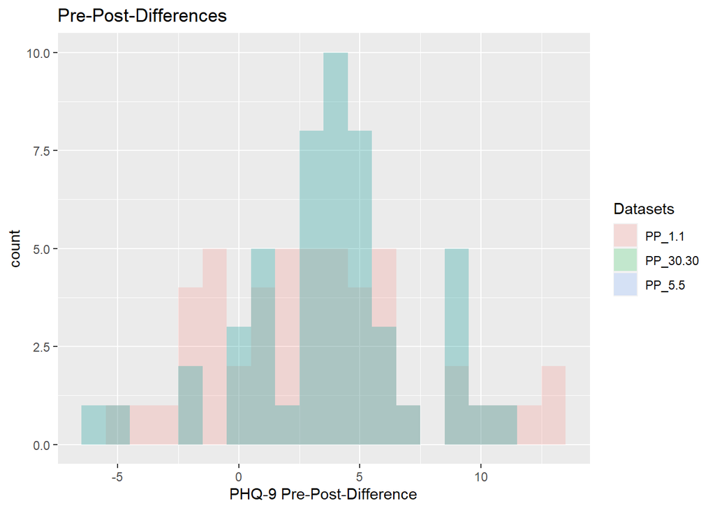

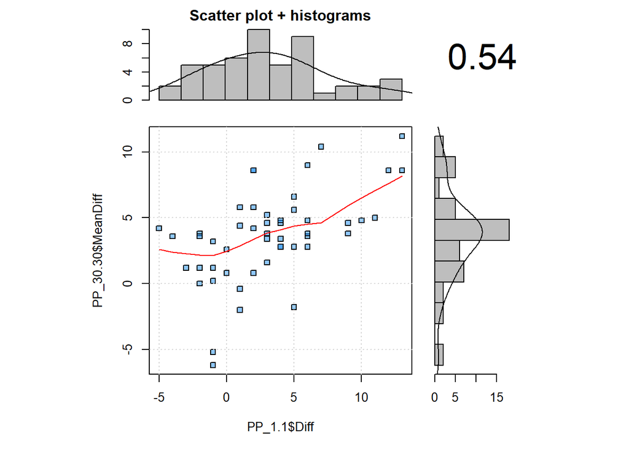

```r
#hist(PP_5.5$MeanDiff, col = "lightblue1", main = paste0("Mittlere Pre-Post-Intervall-Differenz in PP_5.5 = ",
#  round(mean(PP_5.5$MeanDiff), digits = 3)))

#hist(PP_30.30$MeanDiff, col = "lightblue1", main = paste0("Mittlere Pre-Post-Intervall-Differenz in PP_30.30 = ",
#  round(mean(PP_30.30$MeanDiff), digits = 3)))

#hist(PP_1.1$Diff, col = "lightblue1", main = paste0("Mittlere Pre-Post-Differenz in PP_1.1 = ",
#  round(mean(PP_1.1$Diff), digits = 3)))

temp = tibble(MeanDiffs = c(PP_5.5$MeanDiff, PP_30.30$MeanDiff, PP_1.1$Diff),
              Datasets = rep(c("PP_5.5", "PP_30.30", "PP_1.1"), each = length(PP_5.5$MeanDiff)))

temp %>%
  ggplot(aes(x = MeanDiffs, fill = Datasets)) +
    geom_histogram(alpha = 0.2, binwidth = 1, position = "identity") +
    labs(title = "Pre-Post-Differences", x = "PHQ-9 Pre-Post-Difference")

scatter.hist(PP_1.1$Diff, PP_30.30$MeanDiff, xlab = "PP_1.1$Diff",
  ylab = "PP_30.30$MeanDiff", ellipse = FALSE, grid = TRUE, col = c("dodgerblue", "darkorange"))
```

Korrelation zwischen den Pre-Post-Differenzen in PP_1.1 und PP_30.30 = 0.538.

> Prozentuale Überlappung der Pre-Post-(Mittelwerts-)Veränderungen

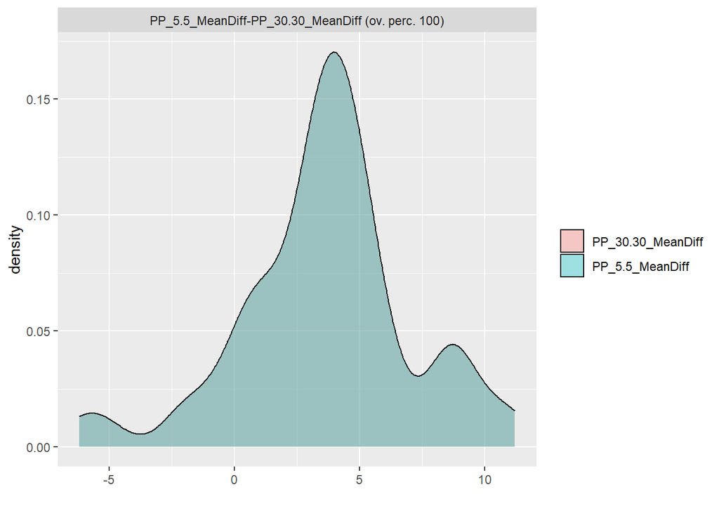

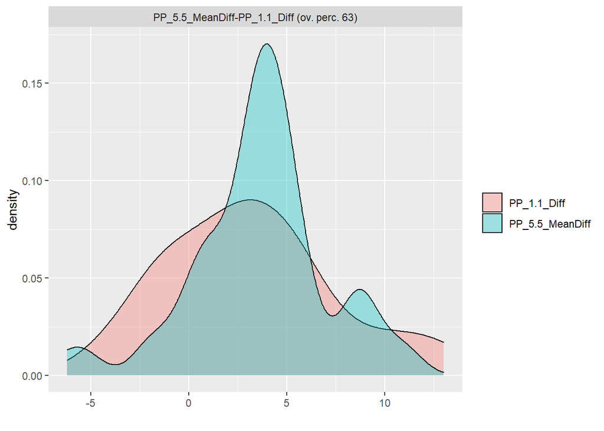

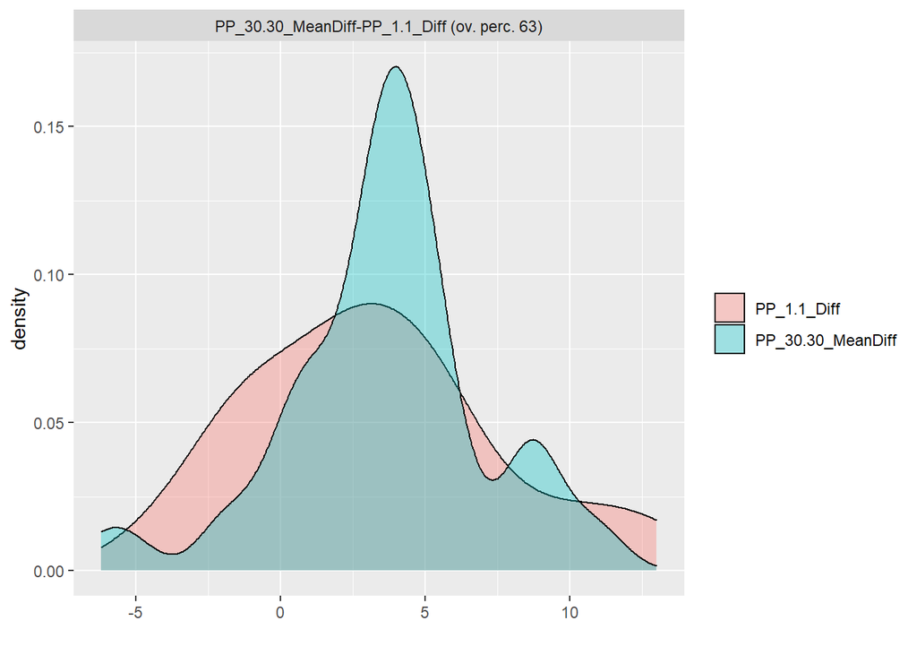

```r
# Overlap-Plots zum Vergleich
final.plot(list(PP_5.5_MeanDiff = PP_5.5$MeanDiff, PP_30.30_MeanDiff = PP_30.30$MeanDiff),
           overlap(list(PP_5.5_MeanDiff = PP_5.5$MeanDiff, PP_30.30_MeanDiff = PP_30.30$MeanDiff))$OV)

final.plot(list(PP_5.5_MeanDiff = PP_5.5$MeanDiff, PP_1.1_Diff = PP_1.1$Diff),
           overlap(list(PP_5.5_MeanDiff = PP_5.5$MeanDiff, PP_1.1_Diff = PP_1.1$Diff))$OV)

final.plot(list(PP_30.30_MeanDiff = PP_30.30$MeanDiff, PP_1.1_Diff = PP_1.1$Diff),
           overlap(list(PP_30.30_MeanDiff = PP_30.30$MeanDiff, PP_1.1_Diff = PP_1.1$Diff))$OV)
```

### 1.5.1 Cohen´s d

> Cohen´s d (mit gepoolten SDs) vom Pre- zum Post-Intervall in den Original-Simulationsdaten (je 5 MZP)

$$d = \frac{\overline{x_{1}} - \overline{x_{2}}} {\sqrt{0.5 \cdot (s_{x}^2 + s_{y}^2)}}$$

$\overline{x_{1}}$ = mean of subject´s pretest scores, $\overline{x_{2}}$ = mean of subject´s posttest scores, $s_{x}$ = individual standard deviation of pretest time points, $s_{y}$ = individual standard deviation of posttest time points

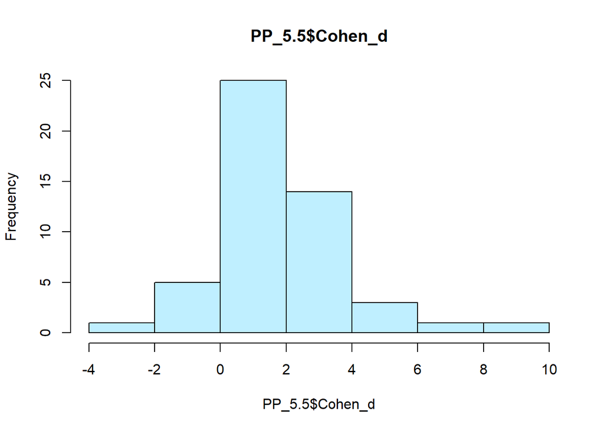

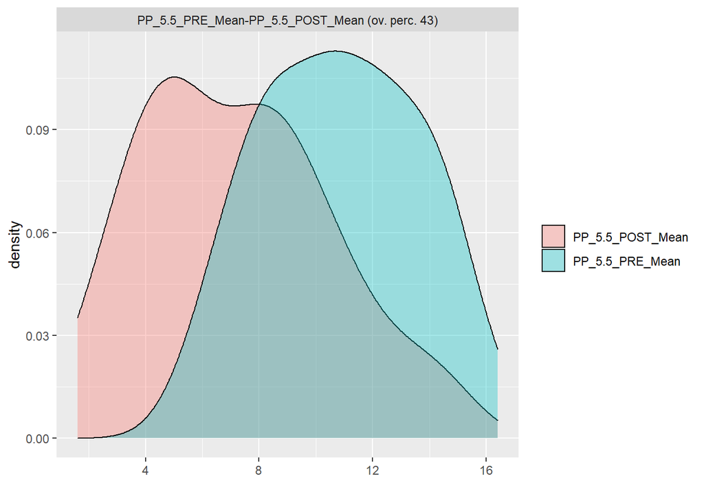

```r
PP_5.5$Cohen_d = (PP_5.5$PRE_Mean - PP_5.5$POST_Mean) / sqrt(0.5 * (PP_5.5$ind.pretestSD^2 + PP_5.5$ind.posttestSD^2))

# Sollen Cohen_d %in% c(-Inf,Inf) ein-/ausgeschlossen werden?
#PP_5.5 = PP_5.5 %>%
#  within(., {Cohen_d[Cohen_d %in% c(-Inf,Inf)] = NA})

hist(PP_5.5$Cohen_d, col = "lightblue1", main = "PP_5.5$Cohen_d")

cohen_d_5.5 = (mean(PP_5.5$PRE_Mean) - mean(PP_5.5$POST_Mean)) / sqrt(0.5 * (mean(PP_5.5$ind.pretestSD)^2 +
  mean(PP_5.5$ind.posttestSD)^2))

final.plot(list(PP_5.5_PRE_Mean = PP_5.5$PRE_Mean, PP_5.5_POST_Mean = PP_5.5$POST_Mean),
           overlap(list(PP_5.5_PRE_Mean = PP_5.5$PRE_Mean, PP_5.5_POST_Mean = PP_5.5$POST_Mean))$OV)
```

Gepoolte Varianz zwischen Pre- und Post-Intervall-Mittelwerten in PP_5.5 = 4.309.  
Durchschnittliches Cohen´s d zwischen Pre- und Post-Mittelwerten (für jede Person einzeln berechnet) in PP_5.5 = 1.748.  
Durchschnittliches Cohen´s d zwischen Pre- und Post-Mittelwerten in PP_5.5 = 1.508.

> Cohen´s d (mit gepoolten SDs) vom Pre- zum Post-Intervall in den erweiterten Intervall-Daten (je 30 MZP)

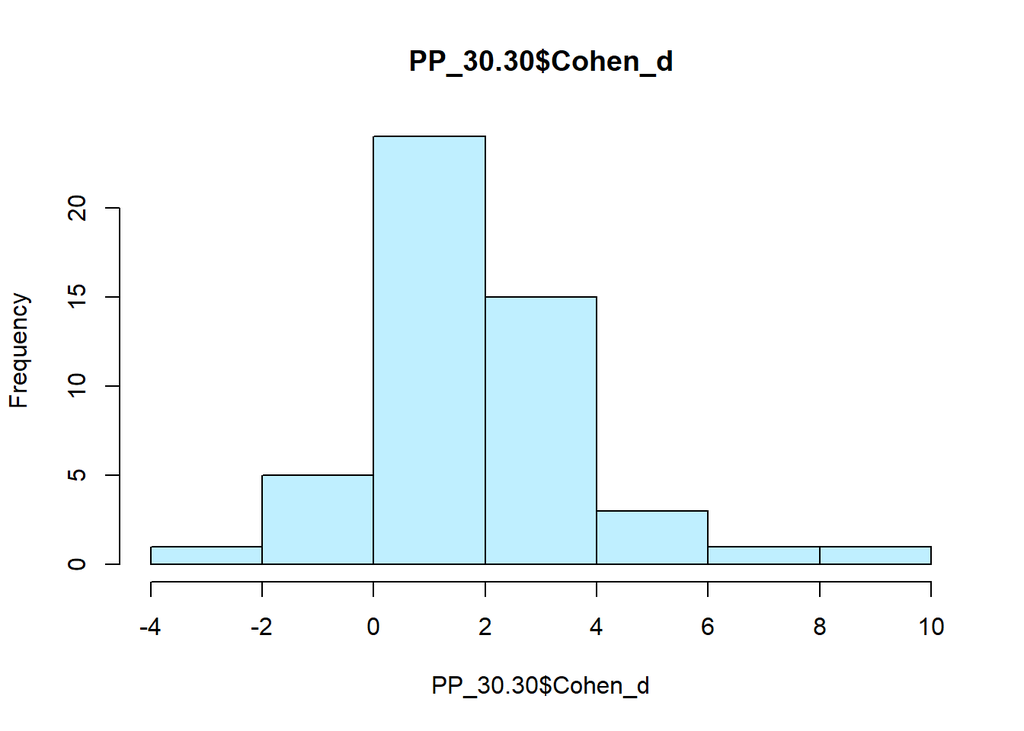

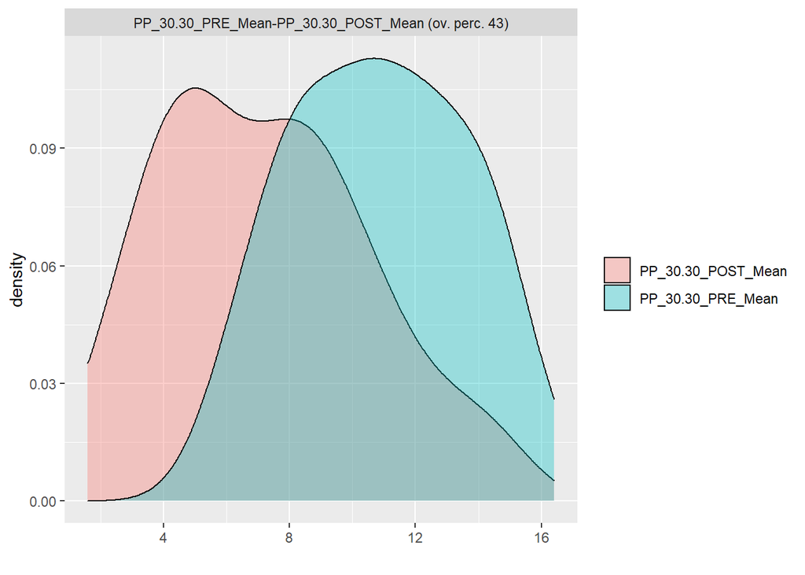

```r
PP_30.30$Cohen_d = (PP_30.30$PRE_Mean - PP_30.30$POST_Mean) / sqrt(0.5 * (PP_30.30$ind.pretestSD^2 +
  PP_30.30$ind.posttestSD^2))

# Sollen Cohen_d %in% c(-Inf,Inf) ein-/ausgeschlossen werden?
#PP_30.30 = PP_30.30 %>%
#  within(., {Cohen_d[Cohen_d %in% c(-Inf,Inf)] = NA})

hist(PP_30.30$Cohen_d, col = "lightblue1", main = "PP_30.30$Cohen_d")

cohen_d_30.30 = (mean(PP_30.30$PRE_Mean) - mean(PP_30.30$POST_Mean)) / sqrt(0.5 * (mean(PP_30.30$ind.pretestSD)^2 + mean(PP_30.30$ind.posttestSD)^2))

final.plot(list(PP_30.30_PRE_Mean = PP_30.30$PRE_Mean, PP_30.30_POST_Mean = PP_30.30$POST_Mean),
           overlap(list(PP_30.30_PRE_Mean = PP_30.30$PRE_Mean, PP_30.30_POST_Mean =
                          PP_30.30$POST_Mean))$OV)
```

> Cohen´s d (mit gepoolten SDs) vom Pre- zum Post-MZP in der Stichprobe mit je 1 MZP

$$d = \frac{\overline{X_{1}} - \overline{X_{2}}} {\sqrt{0.5 \cdot (s_{X}^2 + s_{Y}^2)}}$$

$\overline{X_{1}}$ = mean of pretest scores in the whole sample, $\overline{X_{2}}$ = mean of posttest scores in the whole sample, $s_{X}$ = standard deviation of pretest scores in the whole sample, $s_{Y}$ = standard deviation of posttest scores in the whole sample

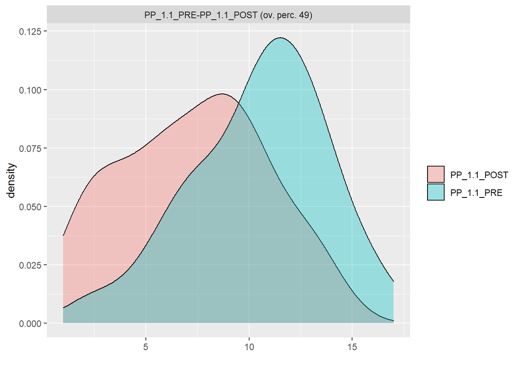

```r
cohen_d_1.1 = (mean(PP_1.1$PRE) - mean(PP_1.1$POST)) / sqrt(0.5 * (sd(PP_1.1$PRE)^2 + sd(PP_1.1$POST)^2))

final.plot(list(PP_1.1_PRE = PP_1.1$PRE, PP_1.1_POST = PP_1.1$POST),
           overlap(list(PP_1.1_PRE = PP_1.1$PRE, PP_1.1_POST = PP_1.1$POST))$OV)
```

Gepoolte Varianz zwischen dem Pre- und Post-MZP in PP_1.1 = 4.808.  
Durchschnittliches Cohen´s d zwischen dem Pre- und Post-MZP in PP_1.1 = 0.929.

## 1.6 Klinische PHQ-9-Interpretation

```r
PHQ_Int = tibble(PHQ_Score = c("0-4","5-9","10-14","15-19","20-27"),
       Klassifikation = c(0,1,2,3,4),
       Interpretation = c("Minimal or none","Mild","Moderate","Moderately severe","Severe"))
```

### 1.6.1 PP_5.5

```r
PP_5.5 = PP_5.5 %>%
  mutate(PRE_Mean_klass = case_when(
    PRE_Mean <= 4 ~ 0,
    PRE_Mean > 4 & PRE_Mean < 10 ~ 1,
    PRE_Mean >= 10 & PRE_Mean < 15 ~ 2,
    PRE_Mean >= 15 & PRE_Mean < 20 ~ 3,
    PRE_Mean >= 20 ~ 4,
    TRUE ~ PRE_Mean
  )
)

temp = PP_5.5 %>%
  dplyr::count(PRE_Mean_klass) %>%
  mutate(Percentage = round(((n / sum(n)) * 100), digits = 2))

PHQ_Int %>%
  dplyr::rename(PRE_Mean_klass = Klassifikation) %>%
  full_join(., temp) %>%
  kable() %>%
  kable_styling(bootstrap_options = c("striped", "hover", "condensed"), full_width = FALSE)
```

| PHQ_Score | PRE_Mean_klass | Interpretation | n | Percentage |
| --- | --- | --- | --- | --- |
| 0-4 | 0 | Minimal or none | NA | NA |
| 5-9 | 1 | Mild | 18 | 36 |
| 10-14 | 2 | Moderate | 29 | 58 |
| 15-19 | 3 | Moderately severe | 3 | 6 |
| 20-27 | 4 | Severe | NA | NA |

```r
PP_5.5 = PP_5.5 %>%
  mutate(POST_Mean_klass = case_when(
    POST_Mean <= 4 ~ 0,
    POST_Mean > 4 & POST_Mean < 10 ~ 1,
    POST_Mean >= 10 & POST_Mean < 15 ~ 2,
    POST_Mean >= 15 & POST_Mean < 20 ~ 3,
    POST_Mean >= 20 ~ 4,
    TRUE ~ POST_Mean
  )
)

temp = PP_5.5 %>%
  dplyr::count(POST_Mean_klass) %>%
  mutate(Percentage = round(((n / sum(n)) * 100), digits = 2))

PHQ_Int %>%
  dplyr::rename(POST_Mean_klass = Klassifikation) %>%
  full_join(., temp) %>%
  kable() %>%
  kable_styling(bootstrap_options = c("striped", "hover", "condensed"), full_width = FALSE)
```

| PHQ_Score | POST_Mean_klass | Interpretation | n | Percentage |
| --- | --- | --- | --- | --- |
| 0-4 | 0 | Minimal or none | 9 | 18 |
| 5-9 | 1 | Mild | 30 | 60 |
| 10-14 | 2 | Moderate | 11 | 22 |
| 15-19 | 3 | Moderately severe | NA | NA |
| 20-27 | 4 | Severe | NA | NA |

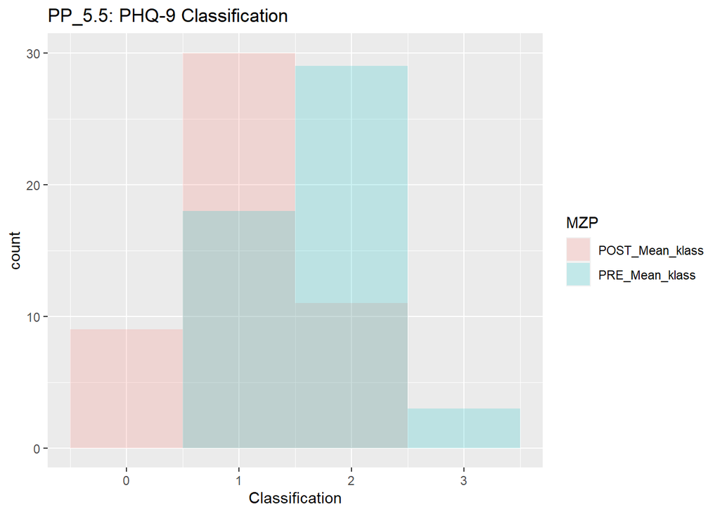

```r
temp = tibble(Klassifikation = c(PP_5.5$PRE_Mean_klass, PP_5.5$POST_Mean_klass),
              MZP = rep(c("PRE_Mean_klass", "POST_Mean_klass"), each = length(PP_5.5$PRE_Mean_klass)))

temp %>%
  ggplot(aes(x = Klassifikation, fill = MZP)) +
    geom_histogram(alpha = 0.2, binwidth = 1, position = "identity") +
    labs(title = "PP_5.5: PHQ-9 Classification", x = "Classification")
```

### 1.6.2 PP_30.30

```r
PP_30.30 = PP_30.30 %>%
  mutate(PRE_Mean_klass = case_when(
    PRE_Mean <= 4 ~ 0,
    PRE_Mean > 4 & PRE_Mean < 10 ~ 1,
    PRE_Mean >= 10 & PRE_Mean < 15 ~ 2,
    PRE_Mean >= 15 & PRE_Mean < 20 ~ 3,
    PRE_Mean >= 20 ~ 4,
    TRUE ~ PRE_Mean
  )
)

temp = PP_30.30 %>%
  dplyr::count(PRE_Mean_klass) %>%
  mutate(Percentage = round(((n / sum(n)) * 100), digits = 2))

PHQ_Int %>%
  dplyr::rename(PRE_Mean_klass = Klassifikation) %>%
  full_join(., temp) %>%
  kable() %>%
  kable_styling(bootstrap_options = c("striped", "hover", "condensed"), full_width = FALSE)
```

| PHQ_Score | PRE_Mean_klass | Interpretation | n | Percentage |
| --- | --- | --- | --- | --- |
| 0-4 | 0 | Minimal or none | NA | NA |
| 5-9 | 1 | Mild | 18 | 36 |
| 10-14 | 2 | Moderate | 29 | 58 |
| 15-19 | 3 | Moderately severe | 3 | 6 |
| 20-27 | 4 | Severe | NA | NA |

```r
PP_30.30 = PP_30.30 %>%
  mutate(POST_Mean_klass = case_when(
    POST_Mean <= 4 ~ 0,
    POST_Mean > 4 & POST_Mean < 10 ~ 1,
    POST_Mean >= 10 & POST_Mean < 15 ~ 2,
    POST_Mean >= 15 & POST_Mean < 20 ~ 3,
    POST_Mean >= 20 ~ 4,
    TRUE ~ POST_Mean
  )
)

temp = PP_30.30 %>%
  dplyr::count(POST_Mean_klass) %>%
  mutate(Percentage = round(((n / sum(n)) * 100), digits = 2))

PHQ_Int %>%
  dplyr::rename(POST_Mean_klass = Klassifikation) %>%
  full_join(., temp) %>%
  kable() %>%
  kable_styling(bootstrap_options = c("striped", "hover", "condensed"), full_width = FALSE)
```

| PHQ_Score | POST_Mean_klass | Interpretation | n | Percentage |
| --- | --- | --- | --- | --- |
| 0-4 | 0 | Minimal or none | 9 | 18 |
| 5-9 | 1 | Mild | 30 | 60 |
| 10-14 | 2 | Moderate | 11 | 22 |
| 15-19 | 3 | Moderately severe | NA | NA |
| 20-27 | 4 | Severe | NA | NA |

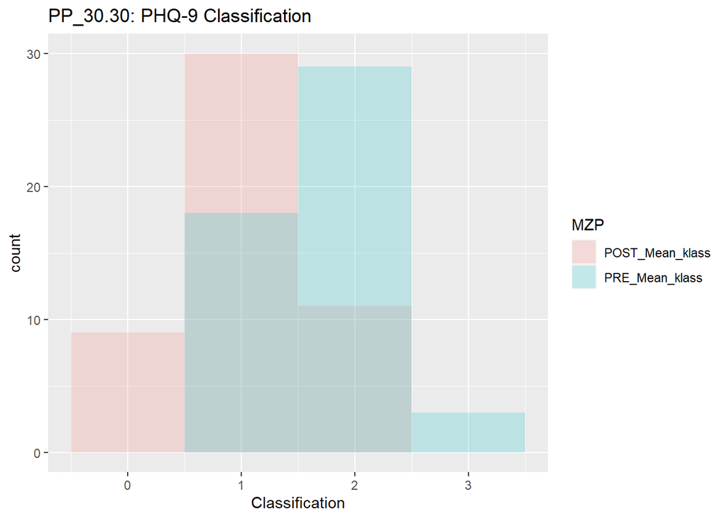

```r
temp = tibble(Klassifikation = c(PP_30.30$PRE_Mean_klass, PP_30.30$POST_Mean_klass),
              MZP = rep(c("PRE_Mean_klass", "POST_Mean_klass"), each = length(PP_30.30$PRE_Mean_klass)))

temp %>%
  ggplot(aes(x = Klassifikation, fill = MZP)) +
    geom_histogram(alpha = 0.2, binwidth = 1, position = "identity") +
    labs(title = "PP_30.30: PHQ-9 Classification", x = "Classification")
```

### 1.6.3 PP_1.1

```r
PP_1.1 = PP_1.1 %>%
  mutate(PRE_klass = case_when(
    PRE <= 4 ~ 0,
    PRE > 4 & PRE < 10 ~ 1,
    PRE >= 10 & PRE < 15 ~ 2,
    PRE >= 15 & PRE < 20 ~ 3,
    PRE >= 20 ~ 4,
    TRUE ~ as.numeric(PRE)
  )
)

temp = PP_1.1 %>%
  dplyr::count(PRE_klass) %>%
  mutate(Percentage = round(((n / sum(n)) * 100), digits = 2))

PHQ_Int %>%
  dplyr::rename(PRE_klass = Klassifikation) %>%
  full_join(., temp) %>%
  kable() %>%
  kable_styling(bootstrap_options = c("striped", "hover", "condensed"), full_width = FALSE)
```

| PHQ_Score | PRE_klass | Interpretation | n | Percentage |
| --- | --- | --- | --- | --- |
| 0-4 | 0 | Minimal or none | 2 | 4 |
| 5-9 | 1 | Mild | 14 | 28 |
| 10-14 | 2 | Moderate | 29 | 58 |
| 15-19 | 3 | Moderately severe | 5 | 10 |
| 20-27 | 4 | Severe | NA | NA |

```r
PP_1.1 = PP_1.1 %>%
  mutate(POST_klass = case_when(
    POST <= 4 ~ 0,
    POST > 4 & POST < 10 ~ 1,
    POST >= 10 & POST < 15 ~ 2,
    POST >= 15 & POST < 20 ~ 3,
    POST >= 20 ~ 4,
    TRUE ~ as.numeric(POST)
  )
)

temp = PP_1.1 %>%
  dplyr::count(POST_klass) %>%
  mutate(Percentage = round(((n / sum(n)) * 100), digits = 2))

PHQ_Int %>%
  dplyr::rename(POST_klass = Klassifikation) %>%
  full_join(., temp) %>%
  kable() %>%
  kable_styling(bootstrap_options = c("striped", "hover", "condensed"), full_width = FALSE)
```

| PHQ_Score | POST_klass | Interpretation | n | Percentage |
| --- | --- | --- | --- | --- |
| 0-4 | 0 | Minimal or none | 12 | 24 |
| 5-9 | 1 | Mild | 24 | 48 |
| 10-14 | 2 | Moderate | 14 | 28 |
| 15-19 | 3 | Moderately severe | NA | NA |
| 20-27 | 4 | Severe | NA | NA |

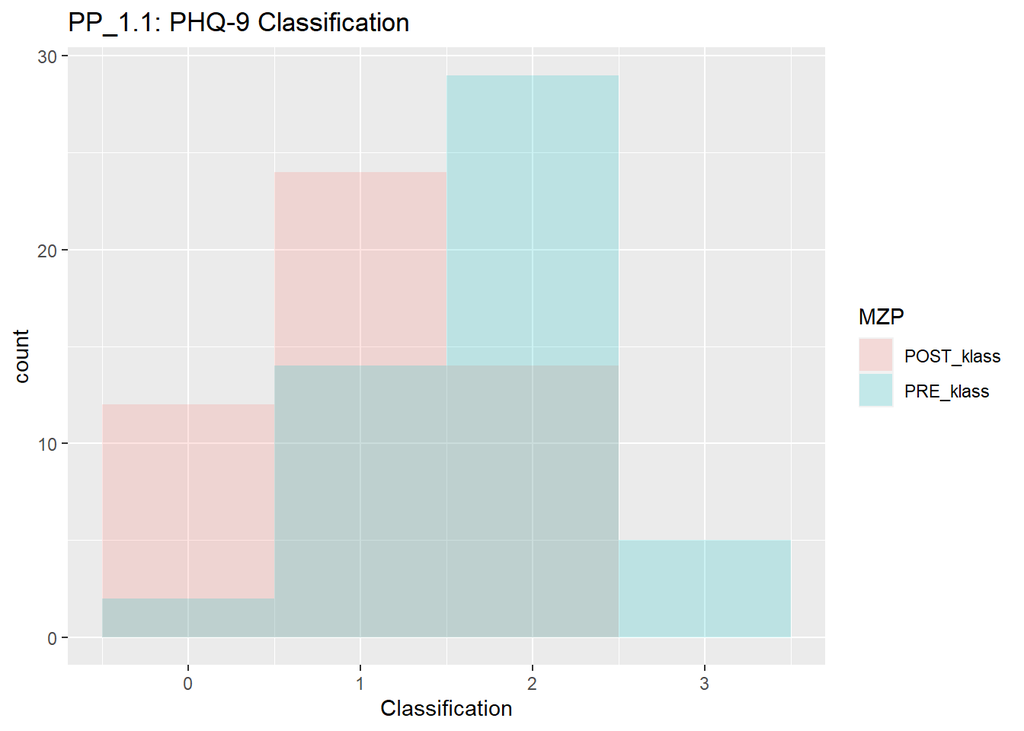

```r
temp = tibble(Klassifikation = c(PP_1.1$PRE_klass, PP_1.1$POST_klass),
              MZP = rep(c("PRE_klass", "POST_klass"), each = length(PP_1.1$PRE_klass)))

temp %>%
  ggplot(aes(x = Klassifikation, fill = MZP)) +
    geom_histogram(alpha = 0.2, binwidth = 1, position = "identity") +
    labs(title = "PP_1.1: PHQ-9 Classification", x = "Classification")
```

## 1.7 Percentage Change (PC)

$$PC = \Bigl(1 - \frac{\overline{x_{2}}} {\overline{x_{1}}}\Bigr) \cdot 100$$

$\overline{x_{2}}$ = mean of subject´s posttest scores, $\overline{x_{1}}$ = mean of subject´s pretest scores

> Interpretation des Percentage Change:

```r
PC_Int = tibble(PC = c("PC <= -50","-50 < PC <= -25","-25 < PC < 25","25 <= PC < 50","PC >= 50"),
                Klassifikation = c(-2,-1,0,1,2),
                Interpretation = c("starke Verschlechterung","Verschlechterung","keine Veränderung",
                                   "Verbesserung","starke Verbesserung"))
```

### 1.7.1 PP_5.5

```r
PP_5.5$Mean_PC = (1-(PP_5.5$POST_Mean / PP_5.5$PRE_Mean)) * 100

# Sollen Mean_PC %in% c(-Inf,Inf) ein-/ausgeschlossen werden?
#PP_5.5 = PP_5.5 %>%
#  within(., {Mean_PC[Mean_PC %in% c(-Inf,Inf)] = NA})

PP_5.5 = PP_5.5 %>%
  mutate(Mean_PC_klass = case_when(
    Mean_PC <= -50 ~ -2,
    Mean_PC > -50 & Mean_PC <= -25 ~ -1,
    Mean_PC > -25 & Mean_PC < 25 ~ 0,
    Mean_PC >= 25 & Mean_PC < 50 ~ 1,
    Mean_PC >= 50 ~ 2,
    TRUE ~ Mean_PC
  )
)


temp = PP_5.5 %>%
  dplyr::count(Mean_PC_klass) %>%
  mutate(Percentage = round(((n / sum(n)) * 100), digits = 2))

PC_Int %>%
  dplyr::rename(Mean_PC_klass = Klassifikation) %>%
  full_join(., temp) %>%
  kable() %>%
  kable_styling(bootstrap_options = c("striped", "hover", "condensed"), full_width = FALSE)
```

| PC | Mean_PC_klass | Interpretation | n | Percentage |
| --- | --- | --- | --- | --- |
| PC <= -50 | -2 | starke Verschlechterung | 2 | 4 |
| -50 < PC <= -25 | -1 | Verschlechterung | 1 | 2 |
| -25 < PC < 25 | 0 | keine Veränderung | 13 | 26 |
| 25 <= PC < 50 | 1 | Verbesserung | 19 | 38 |
| PC >= 50 | 2 | starke Verbesserung | 15 | 30 |

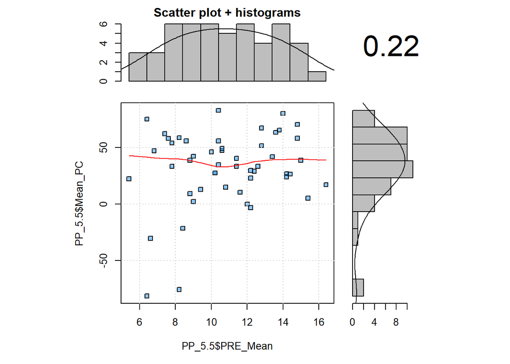

```r
x = PP_5.5 %>%
  within(., {Mean_PC[Mean_PC %in% c(-Inf,Inf)] = NA})

y = PP_5.5 %>%
  within(., {Mean_PC[Mean_PC %in% c(-Inf,Inf)] = NA})

scatter.hist(x$PRE_Mean, y$Mean_PC, xlab = "PP_5.5$PRE_Mean", ylab = "PP_5.5$Mean_PC", ellipse = FALSE, grid = TRUE, col = c("dodgerblue", "darkorange"))
```

Korrelation Mean Percentage Change (je 5 MZP) mit PHQ-Baseline (Pre-Intervall-Mean) = 0.223.

### 1.7.2 PP_30.30

```r
PP_30.30$Mean_PC = (1-(PP_30.30$POST_Mean / PP_30.30$PRE_Mean)) * 100

# Sollen Mean_PC %in% c(-Inf,Inf) ein-/ausgeschlossen werden?
#PP_30.30 = PP_30.30 %>%
#  within(., {Mean_PC[Mean_PC %in% c(-Inf,Inf)] = NA})

PP_30.30 = PP_30.30 %>%
  mutate(Mean_PC_klass = case_when(
    Mean_PC <= -50 ~ -2,
    Mean_PC > -50 & Mean_PC <= -25 ~ -1,
    Mean_PC > -25 & Mean_PC < 25 ~ 0,
    Mean_PC >= 25 & Mean_PC < 50 ~ 1,
    Mean_PC >= 50 ~ 2,
    TRUE ~ Mean_PC
  )
)


temp = PP_30.30 %>%
  dplyr::count(Mean_PC_klass) %>%
  mutate(Percentage = round(((n / sum(n)) * 100), digits = 2))

PC_Int %>%
  dplyr::rename(Mean_PC_klass = Klassifikation) %>%
  full_join(., temp) %>%
  kable() %>%
  kable_styling(bootstrap_options = c("striped", "hover", "condensed"), full_width = FALSE)
```

| PC | Mean_PC_klass | Interpretation | n | Percentage |
| --- | --- | --- | --- | --- |
| PC <= -50 | -2 | starke Verschlechterung | 2 | 4 |
| -50 < PC <= -25 | -1 | Verschlechterung | 1 | 2 |
| -25 < PC < 25 | 0 | keine Veränderung | 13 | 26 |
| 25 <= PC < 50 | 1 | Verbesserung | 19 | 38 |
| PC >= 50 | 2 | starke Verbesserung | 15 | 30 |

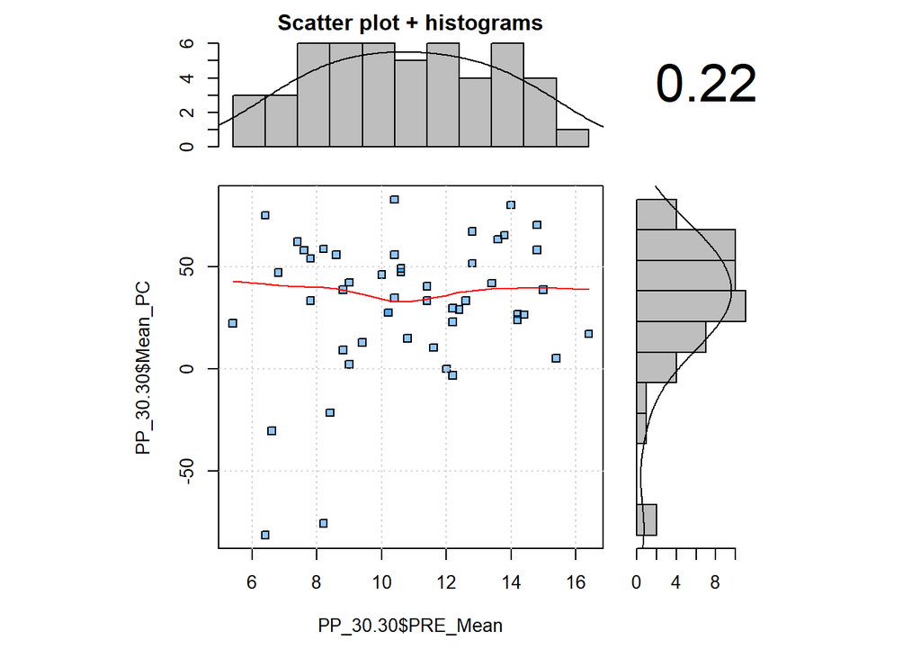

```r
x = PP_30.30 %>%
  within(., {Mean_PC[Mean_PC %in% c(-Inf,Inf)] = NA})

y = PP_30.30 %>%
  within(., {Mean_PC[Mean_PC %in% c(-Inf,Inf)] = NA})

scatter.hist(x$PRE_Mean, y$Mean_PC, xlab = "PP_30.30$PRE_Mean", ylab = "PP_30.30$Mean_PC", ellipse = FALSE, grid = TRUE, col = c("dodgerblue", "darkorange"))
```

Korrelation Mean Percentage Change (je 30 MZP) mit PHQ-Baseline (Pre-Intervall-Mean) = 0.223.

### 1.7.3 PP_1.1

```r
PP_1.1$PC = (1 - (PP_1.1$POST / PP_1.1$PRE)) * 100

# Sollen PC %in% c(-Inf,Inf) ein-/ausgeschlossen werden?
#PP_1.1 = PP_1.1 %>%
#  within(., {PC[PC %in% c(-Inf,Inf)] = NA})

PP_1.1 = PP_1.1 %>%
  mutate(PC_klass = case_when(
    PC <= -50 ~ -2,
    PC > -50 & PC <= -25 ~ -1,
    PC > -25 & PC < 25 ~ 0,
    PC >= 25 & PC < 50 ~ 1,
    PC >= 50 ~ 2,
    TRUE ~ as.numeric(PC)
  )
)


temp = PP_1.1 %>%
  dplyr::count(PC_klass) %>%
  mutate(Percentage = round(((n / sum(n)) * 100), digits = 2))

PC_Int %>%
  dplyr::rename(PC_klass = Klassifikation) %>%
  full_join(., temp) %>%
  kable() %>%
  kable_styling(bootstrap_options = c("striped", "hover", "condensed"), full_width = FALSE)
```

| PC | PC_klass | Interpretation | n | Percentage |
| --- | --- | --- | --- | --- |
| PC <= -50 | -2 | starke Verschlechterung | 3 | 6 |
| -50 < PC <= -25 | -1 | Verschlechterung | 2 | 4 |
| -25 < PC < 25 | 0 | keine Veränderung | 18 | 36 |
| 25 <= PC < 50 | 1 | Verbesserung | 13 | 26 |
| PC >= 50 | 2 | starke Verbesserung | 14 | 28 |

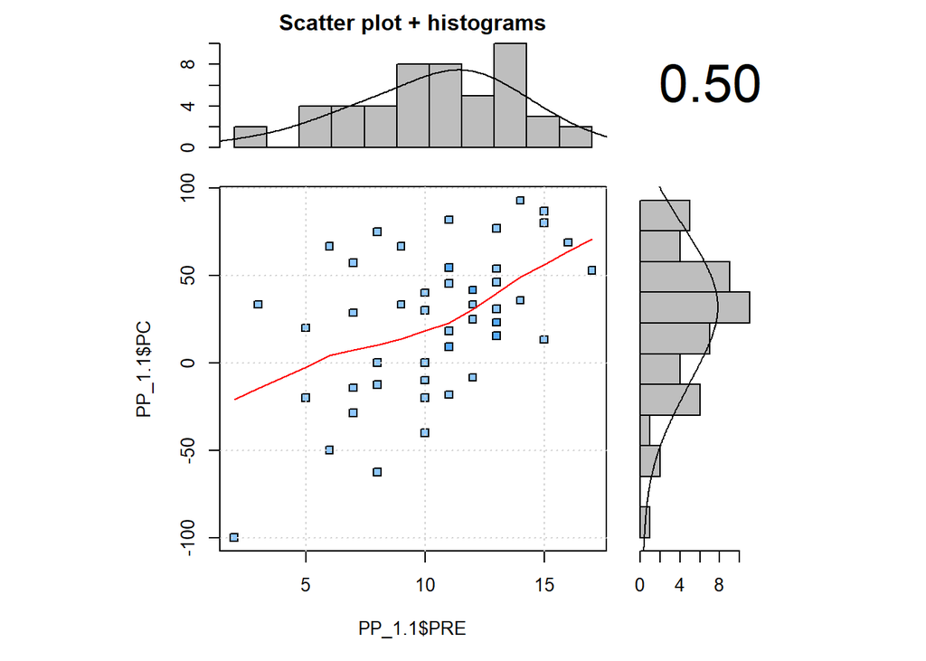

```r
x = PP_1.1 %>%
  within(., {PC[PC %in% c(-Inf,Inf)] = NA})

y = PP_1.1 %>%
  within(., {PC[PC %in% c(-Inf,Inf)] = NA})

scatter.hist(x$PRE, y$PC, xlab = "PP_1.1$PRE", ylab = "PP_1.1$PC", ellipse = FALSE, grid = TRUE, col = c("dodgerblue", "darkorange"))
```

Korrelation von Percentage Change (je 1 MZP) mit PHQ-Baseline (Pre-MZP) = 0.503.

### 1.7.4 Zusammenhang im Scatter-Histogramm

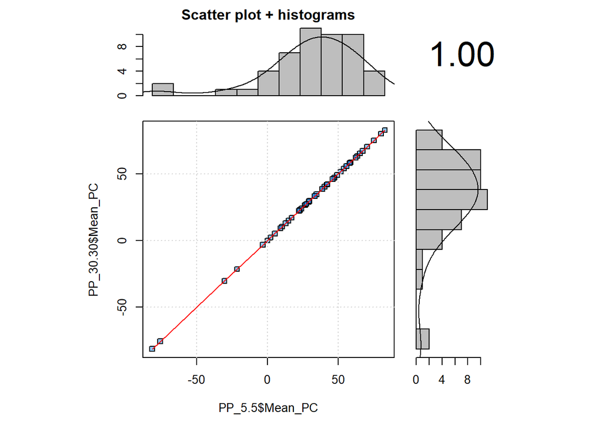

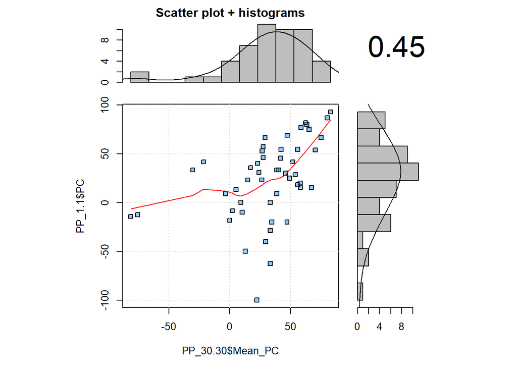

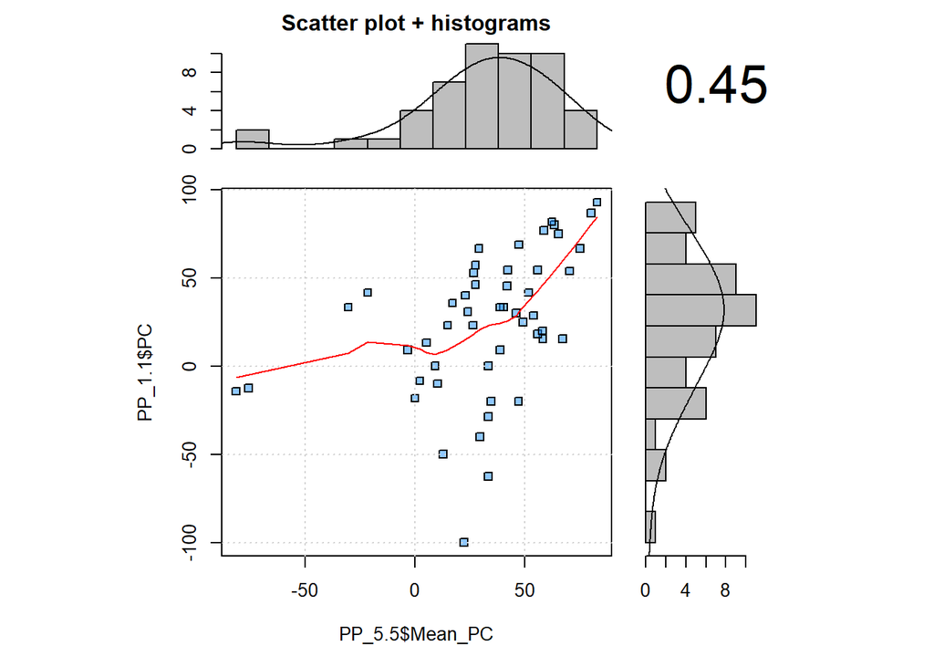

```r
x = PP_5.5 %>%
  within(., {Mean_PC[Mean_PC %in% c(-Inf,Inf)] = NA})

y = PP_30.30 %>%
  within(., {Mean_PC[Mean_PC %in% c(-Inf,Inf)] = NA})

z = PP_1.1 %>%
  within(., {PC[PC %in% c(-Inf,Inf)] = NA})

scatter.hist(x$Mean_PC, y$Mean_PC, xlab = "PP_5.5$Mean_PC", ylab = "PP_30.30$Mean_PC", ellipse = FALSE, grid = TRUE, col = c("dodgerblue", "darkorange"))

scatter.hist(y$Mean_PC, z$PC, xlab = "PP_30.30$Mean_PC", ylab = "PP_1.1$PC", ellipse = FALSE, grid = TRUE, col = c("dodgerblue", "darkorange"))

scatter.hist(x$Mean_PC, z$PC, xlab = "PP_5.5$Mean_PC", ylab = "PP_1.1$PC", ellipse = FALSE, grid = TRUE, col = c("dodgerblue", "darkorange"))
```

## 1.8 Reliable Change Index (JT)

$$RCI = \frac{x_{2} - x_{1}} {s_{diff}}$$

$$s_{diff} = \sqrt{2 \cdot (S_{E})^2}$$

$$SE = s_{1} \cdot \sqrt{1 - r_{xx´}}$$

$$\text{significance cutoff} = 1.96 \cdot s_{diff} = 1.96 \cdot \sqrt{2 \cdot (s_{1} \cdot \sqrt{1 - r_{xx´}})^2}$$

$x_{2}$ = subject´s posttest score, $x_{1}$ = subject´s pretest score, $s_{diff}$ = standard error of difference between test scores, $SE$ = standard error of measurement, $s_{1}$ = standard deviation of test scores at pretest, $r_{xx´}$ = reliability of the measure, $\text{significance cutoff}$ = (absolute) cutoff score for reliable change (95%-criterion)

```r
PP_5.5_RCI_JT_Mean = (mean(PP_5.5$POST_Mean) - mean(PP_5.5$PRE_Mean)) / sqrt(2 * (sd(PP_5.5$PRE_Mean) * sqrt(1 - PP_5.5_Alpha)) ^ 2)

PP_30.30_RCI_JT_Mean = (mean(PP_30.30$POST_Mean) - mean(PP_30.30$PRE_Mean)) / sqrt(2 * (sd(PP_30.30$PRE_Mean) * sqrt(1 - PP_5.5_Alpha)) ^ 2)

PP_1.1_RCI_JT_Mean = (mean(PP_1.1$POST) - mean(PP_1.1$PRE)) / sqrt(2 * (sd(PP_1.1$PRE) * sqrt(1 -
  PP_5.5_Alpha)) ^ 2)
```

Durchschnittlicher RCI(JT) auf Stichproben-Ebene in PP_5.5 = -2.389.  
Durchschnittlicher RCI(JT) auf Stichproben-Ebene in PP_30.30 = -2.389.  
Durchschnittlicher RCI(JT) auf Stichproben-Ebene in PP_1.1 = -1.759.

> RCI(JT) von einem Pre- zu einem Post-MZP (= original für jede Person individuell)

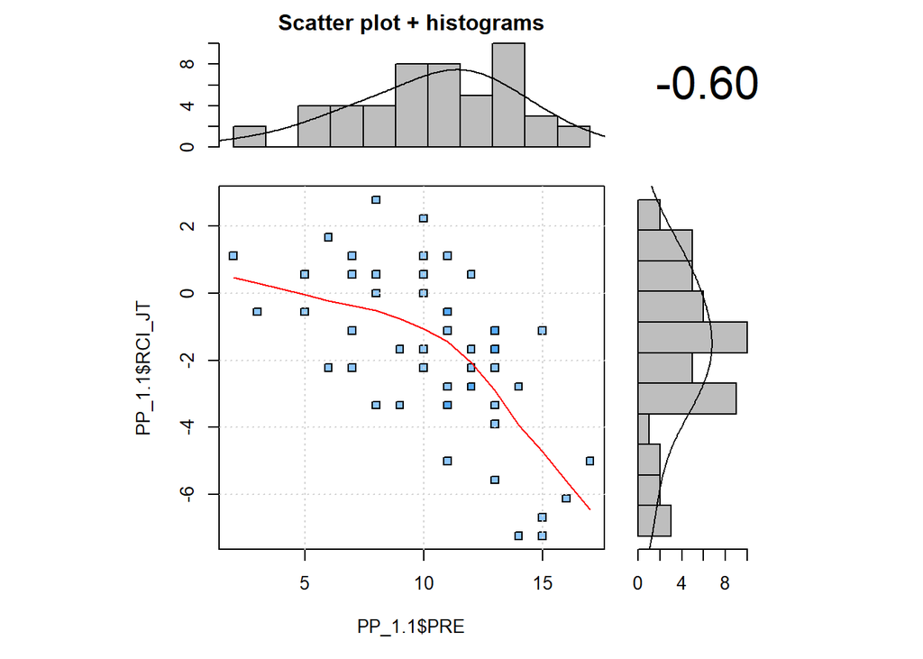

```r
PP_1.1$RCI_JT = (PP_1.1$POST - PP_1.1$PRE) / sqrt(2 * (sd(PP_1.1$PRE) * sqrt(1 - PP_5.5_Alpha)) ^ 2)
RCI_JT_Cutoff = 1.96 * sqrt(2 * (sd(PP_1.1$PRE) * sqrt(1 - PP_5.5_Alpha)) ^ 2)

# Sollen RCI_JT %in% c(-Inf,Inf) ein-/ausgeschlossen werden?
#PP_1.1 = PP_1.1 %>%
#  within(., {RCI_JT[RCI_JT %in% c(-Inf,Inf)] = NA})

x = PP_1.1 %>%
  within(., {RCI_JT[RCI_JT %in% c(-Inf,Inf)] = NA})

y = PP_1.1 %>%
  within(., {RCI_JT[RCI_JT %in% c(-Inf,Inf)] = NA})

scatter.hist(x$PRE, y$RCI_JT, xlab = "PP_1.1$PRE", ylab = "PP_1.1$RCI_JT", ellipse = FALSE, grid = TRUE, col = c("dodgerblue", "darkorange"))
```

Korrelation RCI_JT (je 1 MZP) mit PHQ-Baseline (Pre-MZP) = -0.605.  
RCI(JT)-Cutoff für reliable Veränderung auf Gruppenebene (je 1 MZP) = 3.521.

> Zwischenschritt vom RCI(JT) zum RCI(ind): Der Zähler in der Formel wird durch die Intervall-Differenz (5MZP Pre - 5MZP Post) ausgetauscht:

$$RCI_{Zwischenstufe} = \frac{\overline{x_{2}} - \overline{x_{1}}} {s_{diff}}$$

$\overline{x_{2}}$ = mean of subject´s posttest scores, $\overline{x_{1}}$ = mean of subject´s pretest scores

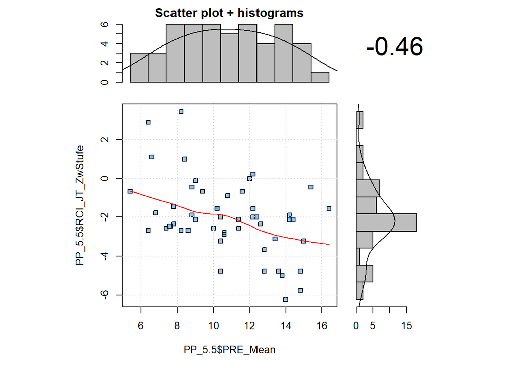

```r
PP_5.5$RCI_JT_ZwStufe = (PP_5.5$POST_Mean - PP_5.5$PRE_Mean) / sqrt(2 * (sd(PP_5.5$PRE1_1) * sqrt(1 - PP_5.5_Alpha)) ^ 2)

# Sollen RCI_JT_ZwStufe %in% c(-Inf,Inf) ein-/ausgeschlossen werden?
#PP_5.5 = PP_5.5 %>%
#  within(., {RCI_JT_ZwStufe[RCI_JT_ZwStufe %in% c(-Inf,Inf)] = NA})

x = PP_5.5 %>%
  within(., {RCI_JT_ZwStufe[RCI_JT_ZwStufe %in% c(-Inf,Inf)] = NA})

y = PP_5.5 %>%
  within(., {RCI_JT_ZwStufe[RCI_JT_ZwStufe %in% c(-Inf,Inf)] = NA})

scatter.hist(x$PRE_Mean, y$RCI_JT_ZwStufe, xlab = "PP_5.5$PRE_Mean", ylab = "PP_5.5$RCI_JT_ZwStufe", ellipse = FALSE, grid = TRUE, col = c("dodgerblue", "darkorange"))
```

Korrelation RCI_JT_ZwStufe (je 5 MZP) mit PHQ-Baseline (Pre-Intervall-Mean) = -0.458.